# examples_future

## Possible successful route 3

- Guess that $(x-2)$ is a factor:

  |  | 1 | 4 | -7 | -10 |
  | --- | --- | --- | --- | --- |
  | 2 |  | 2 | 12 | 10 |
  |  | 1 | 6 | 5 | 0 |

  Notice, the remainder is 0, so the guess was good! So, we rephrase the original equation into a semi-factored form.
  $$(x-{2})(x^{2}+{6}x+{5})=0$$
  Then factor the quadratic expression to get the fully factored form of the equation.
  $$(x-2)(x+1)(x+5)=0$$
  Thus the solutions are: {-5, -1, 2}

Solve:

$$x^3+5x^2+8x-96=0$$

- The real solution:
- The first complex solution: -$i$
- The other complex solution: +$i$

*Hint: the real solution is an integer between -6 and 6. Also the [rational root theorem](https://en.wikipedia.org/wiki/Rational_root_theorem) places additional constraints on possible real solutions. [Descarte's rule of signs](https://en.wikipedia.org/wiki/Descartes%27_rule_of_signs) can also help eliminate possibilities.*

- Guess that $(x-3)$ is a factor:

  |  | 1 | 5 | 8 | -96 |
  | --- | --- | --- | --- | --- |
  | 3 |  | 3 | 24 | 96 |
  |  | 1 | 8 | 32 | 0 |

  Notice, the remainder is 0, so the guess was good! So, we rephrase the original equation into a semi-factored form.
  $$(x-{3})(x^{2}+{8}x+{32})=0$$
  I would recommend using quadratic formula to determine the complex roots.
  $$a=1$$
  $$b=8$$
  $$c=32$$

Plug numbers into the quadratic formula.

$$x =
\frac{-(8)\pm\sqrt{(8)^2-4(1)(32)}}{2(1)}$$

Simplify.

$$x = \frac{-8 \pm
\sqrt{-64}}{2}$$

$$x = \frac{-8 \pm 8i}{2}$$

$$x = -4+4i ~~~~~~~~\text{ OR }~~~~~~~~
x=-4-4i$$

We could rewrite the original equation in fully factored form.

$$\Big(x-(3)\Big)\cdot\Big(x-(-4-4i)\Big)\cdot\Big(x-(-4+4i)\Big)~~=~~0$$

The solutions are:
$$x = 3$$
$$x = -4-4i$$
$$x
= -4+4i$$

Solve:

$$x^3-7x^2+96x-90=0$$

- The real solution:
- The first complex solution: -$i$
- The other complex solution: +$i$

*Hint: the real solution is an integer between -6 and 6. Also the [rational root theorem](https://en.wikipedia.org/wiki/Rational_root_theorem) places additional constraints on possible real solutions. [Descarte's rule of signs](https://en.wikipedia.org/wiki/Descartes%27_rule_of_signs) can also help eliminate possibilities.*

- Guess that $(x-1)$ is a factor:

  |  | 1 | -7 | 96 | -90 |
  | --- | --- | --- | --- | --- |
  | 1 |  | 1 | -6 | 90 |
  |  | 1 | -6 | 90 | 0 |

  Notice, the remainder is 0, so the guess was good! So, we rephrase the original equation into a semi-factored form.
  $$(x-{1})(x^{2}-{6}x+{90})=0$$
  I would recommend using quadratic formula to determine the complex roots.
  $$a=1$$
  $$b=-6$$
  $$c=90$$

Plug numbers into the quadratic formula.

$$x =
\frac{-(-6)\pm\sqrt{(-6)^2-4(1)(90)}}{2(1)}$$

Simplify.

$$x = \frac{6 \pm
\sqrt{-324}}{2}$$

$$x = \frac{6 \pm 18i}{2}$$

$$x = 3+9i ~~~~~~~~\text{ OR }~~~~~~~~
x=3-9i$$

We could rewrite the original equation in fully factored form.

$$\Big(x-(1)\Big)\cdot\Big(x-(3-9i)\Big)\cdot\Big(x-(3+9i)\Big)~~=~~0$$

The solutions are:
$$x = 1$$
$$x = 3-9i$$
$$x
= 3+9i$$

Solve:

$$x^3-5x^2+12x-8=0$$

- The real solution:
- The first complex solution: -$i$
- The other complex solution: +$i$

*Hint: the real solution is an integer between -6 and 6. Also the [rational root theorem](https://en.wikipedia.org/wiki/Rational_root_theorem) places additional constraints on possible real solutions. [Descarte's rule of signs](https://en.wikipedia.org/wiki/Descartes%27_rule_of_signs) can also help eliminate possibilities.*

- Guess that $(x-1)$ is a factor:

  |  | 1 | -5 | 12 | -8 |
  | --- | --- | --- | --- | --- |
  | 1 |  | 1 | -4 | 8 |
  |  | 1 | -4 | 8 | 0 |

  Notice, the remainder is 0, so the guess was good! So, we rephrase the original equation into a semi-factored form.
  $$(x-{1})(x^{2}-{4}x+{8})=0$$
  I would recommend using quadratic formula to determine the complex roots.
  $$a=1$$
  $$b=-4$$
  $$c=8$$

Plug numbers into the quadratic formula.

$$x =
\frac{-(-4)\pm\sqrt{(-4)^2-4(1)(8)}}{2(1)}$$

Simplify.

$$x = \frac{4 \pm
\sqrt{-16}}{2}$$

$$x = \frac{4 \pm 4i}{2}$$

$$x = 2+2i ~~~~~~~~\text{ OR }~~~~~~~~
x=2-2i$$

We could rewrite the original equation in fully factored form.

$$\Big(x-(1)\Big)\cdot\Big(x-(2-2i)\Big)\cdot\Big(x-(2+2i)\Big)~~=~~0$$

The solutions are:
$$x = 1$$
$$x = 2-2i$$
$$x
= 2+2i$$

Solve:

$$x^3-8x-32=0$$

- The real solution:
- The first complex solution: -$i$
- The other complex solution: +$i$

*Hint: the real solution is an integer between -6 and 6. Also the [rational root theorem](https://en.wikipedia.org/wiki/Rational_root_theorem) places additional constraints on possible real solutions. [Descarte's rule of signs](https://en.wikipedia.org/wiki/Descartes%27_rule_of_signs) can also help eliminate possibilities.*

- Guess that $(x-4)$ is a factor:

  |  | 1 | 0 | -8 | -32 |
  | --- | --- | --- | --- | --- |
  | 4 |  | 4 | 16 | 32 |
  |  | 1 | 4 | 8 | 0 |

  Notice, the remainder is 0, so the guess was good! So, we rephrase the original equation into a semi-factored form.
  $$(x-{4})(x^{2}+{4}x+{8})=0$$
  I would recommend using quadratic formula to determine the complex roots.
  $$a=1$$
  $$b=4$$
  $$c=8$$

Plug numbers into the quadratic formula.

$$x =
\frac{-(4)\pm\sqrt{(4)^2-4(1)(8)}}{2(1)}$$

Simplify.

$$x = \frac{-4 \pm
\sqrt{-16}}{2}$$

$$x = \frac{-4 \pm 4i}{2}$$

$$x = -2+2i ~~~~~~~~\text{ OR }~~~~~~~~
x=-2-2i$$

We could rewrite the original equation in fully factored form.

$$\Big(x-(4)\Big)\cdot\Big(x-(-2-2i)\Big)\cdot\Big(x-(-2+2i)\Big)~~=~~0$$

The solutions are:
$$x = 4$$
$$x = -2-2i$$
$$x
= -2+2i$$

Solve:

$$x^3+7x^2+19x+13=0$$

- The real solution:
- The first complex solution: -$i$
- The other complex solution: +$i$

*Hint: the real solution is an integer between -6 and 6. Also the [rational root theorem](https://en.wikipedia.org/wiki/Rational_root_theorem) places additional constraints on possible real solutions. [Descarte's rule of signs](https://en.wikipedia.org/wiki/Descartes%27_rule_of_signs) can also help eliminate possibilities.*

- Guess that $(x+1)$ is a factor:

  |  | 1 | 7 | 19 | 13 |
  | --- | --- | --- | --- | --- |
  | -1 |  | -1 | -6 | -13 |
  |  | 1 | 6 | 13 | 0 |

  Notice, the remainder is 0, so the guess was good! So, we rephrase the original equation into a semi-factored form.
  $$(x+{1})(x^{2}+{6}x+{13})=0$$
  I would recommend using quadratic formula to determine the complex roots.
  $$a=1$$
  $$b=6$$
  $$c=13$$

Plug numbers into the quadratic formula.

$$x =
\frac{-(6)\pm\sqrt{(6)^2-4(1)(13)}}{2(1)}$$

Simplify.

$$x = \frac{-6 \pm
\sqrt{-16}}{2}$$

$$x = \frac{-6 \pm 4i}{2}$$

$$x = -3+2i ~~~~~~~~\text{ OR }~~~~~~~~
x=-3-2i$$

We could rewrite the original equation in fully factored form.

$$\Big(x-(-1)\Big)\cdot\Big(x-(-3-2i)\Big)\cdot\Big(x-(-3+2i)\Big)~~=~~0$$

The solutions are:
$$x = -1$$
$$x = -3-2i$$
$$x
= -3+2i$$

Solve:

$$x^3+4x-80=0$$

- The real solution:
- The first complex solution: -$i$
- The other complex solution: +$i$

*Hint: the real solution is an integer between -6 and 6. Also the [rational root theorem](https://en.wikipedia.org/wiki/Rational_root_theorem) places additional constraints on possible real solutions. [Descarte's rule of signs](https://en.wikipedia.org/wiki/Descartes%27_rule_of_signs) can also help eliminate possibilities.*

- Guess that $(x-4)$ is a factor:

  |  | 1 | 0 | 4 | -80 |
  | --- | --- | --- | --- | --- |
  | 4 |  | 4 | 16 | 80 |
  |  | 1 | 4 | 20 | 0 |

  Notice, the remainder is 0, so the guess was good! So, we rephrase the original equation into a semi-factored form.
  $$(x-{4})(x^{2}+{4}x+{20})=0$$
  I would recommend using quadratic formula to determine the complex roots.
  $$a=1$$
  $$b=4$$
  $$c=20$$

Plug numbers into the quadratic formula.

$$x =
\frac{-(4)\pm\sqrt{(4)^2-4(1)(20)}}{2(1)}$$

Simplify.

$$x = \frac{-4 \pm
\sqrt{-64}}{2}$$

$$x = \frac{-4 \pm 8i}{2}$$

$$x = -2+4i ~~~~~~~~\text{ OR }~~~~~~~~
x=-2-4i$$

We could rewrite the original equation in fully factored form.

$$\Big(x-(4)\Big)\cdot\Big(x-(-2-4i)\Big)\cdot\Big(x-(-2+4i)\Big)~~=~~0$$

The solutions are:
$$x = 4$$
$$x = -2-4i$$
$$x
= -2+4i$$

Solve:

$$x^3-5x^2+16x-30=0$$

- The real solution:
- The first complex solution: -$i$
- The other complex solution: +$i$

*Hint: the real solution is an integer between -6 and 6. Also the [rational root theorem](https://en.wikipedia.org/wiki/Rational_root_theorem) places additional constraints on possible real solutions. [Descarte's rule of signs](https://en.wikipedia.org/wiki/Descartes%27_rule_of_signs) can also help eliminate possibilities.*

- Guess that $(x-3)$ is a factor:

  |  | 1 | -5 | 16 | -30 |
  | --- | --- | --- | --- | --- |
  | 3 |  | 3 | -6 | 30 |
  |  | 1 | -2 | 10 | 0 |

  Notice, the remainder is 0, so the guess was good! So, we rephrase the original equation into a semi-factored form.
  $$(x-{3})(x^{2}-{2}x+{10})=0$$
  I would recommend using quadratic formula to determine the complex roots.
  $$a=1$$
  $$b=-2$$
  $$c=10$$

Plug numbers into the quadratic formula.

$$x =
\frac{-(-2)\pm\sqrt{(-2)^2-4(1)(10)}}{2(1)}$$

Simplify.

$$x = \frac{2 \pm
\sqrt{-36}}{2}$$

$$x = \frac{2 \pm 6i}{2}$$

$$x = 1+3i ~~~~~~~~\text{ OR }~~~~~~~~
x=1-3i$$

We could rewrite the original equation in fully factored form.

$$\Big(x-(3)\Big)\cdot\Big(x-(1-3i)\Big)\cdot\Big(x-(1+3i)\Big)~~=~~0$$

The solutions are:
$$x = 3$$
$$x = 1-3i$$
$$x
= 1+3i$$

Solve:

$$x^3-4x^2+13x+50=0$$

- The real solution:
- The first complex solution: -$i$
- The other complex solution: +$i$

*Hint: the real solution is an integer between -6 and 6. Also the [rational root theorem](https://en.wikipedia.org/wiki/Rational_root_theorem) places additional constraints on possible real solutions. [Descarte's rule of signs](https://en.wikipedia.org/wiki/Descartes%27_rule_of_signs) can also help eliminate possibilities.*

- Guess that $(x+2)$ is a factor:

  |  | 1 | -4 | 13 | 50 |
  | --- | --- | --- | --- | --- |
  | -2 |  | -2 | 12 | -50 |
  |  | 1 | -6 | 25 | 0 |

  Notice, the remainder is 0, so the guess was good! So, we rephrase the original equation into a semi-factored form.
  $$(x+{2})(x^{2}-{6}x+{25})=0$$
  I would recommend using quadratic formula to determine the complex roots.
  $$a=1$$
  $$b=-6$$
  $$c=25$$

Plug numbers into the quadratic formula.

$$x =
\frac{-(-6)\pm\sqrt{(-6)^2-4(1)(25)}}{2(1)}$$

Simplify.

$$x = \frac{6 \pm
\sqrt{-64}}{2}$$

$$x = \frac{6 \pm 8i}{2}$$

$$x = 3+4i ~~~~~~~~\text{ OR }~~~~~~~~
x=3-4i$$

We could rewrite the original equation in fully factored form.

$$\Big(x-(-2)\Big)\cdot\Big(x-(3-4i)\Big)\cdot\Big(x-(3+4i)\Big)~~=~~0$$

The solutions are:
$$x = -2$$
$$x = 3-4i$$
$$x
= 3+4i$$

Solve:

$$x^3-11x^2+44x-60=0$$

- The real solution:
- The first complex solution: -$i$
- The other complex solution: +$i$

*Hint: the real solution is an integer between -6 and 6. Also the [rational root theorem](https://en.wikipedia.org/wiki/Rational_root_theorem) places additional constraints on possible real solutions. [Descarte's rule of signs](https://en.wikipedia.org/wiki/Descartes%27_rule_of_signs) can also help eliminate possibilities.*

- Guess that $(x-3)$ is a factor:

  |  | 1 | -11 | 44 | -60 |
  | --- | --- | --- | --- | --- |
  | 3 |  | 3 | -24 | 60 |
  |  | 1 | -8 | 20 | 0 |

  Notice, the remainder is 0, so the guess was good! So, we rephrase the original equation into a semi-factored form.
  $$(x-{3})(x^{2}-{8}x+{20})=0$$
  I would recommend using quadratic formula to determine the complex roots.
  $$a=1$$
  $$b=-8$$
  $$c=20$$

Plug numbers into the quadratic formula.

$$x =
\frac{-(-8)\pm\sqrt{(-8)^2-4(1)(20)}}{2(1)}$$

Simplify.

$$x = \frac{8 \pm
\sqrt{-16}}{2}$$

$$x = \frac{8 \pm 4i}{2}$$

$$x = 4+2i ~~~~~~~~\text{ OR }~~~~~~~~
x=4-2i$$

We could rewrite the original equation in fully factored form.

$$\Big(x-(3)\Big)\cdot\Big(x-(4-2i)\Big)\cdot\Big(x-(4+2i)\Big)~~=~~0$$

The solutions are:
$$x = 3$$
$$x = 4-2i$$
$$x
= 4+2i$$

Solve:

$$x^3-3x^2+36x+40=0$$

- The real solution:
- The first complex solution: -$i$
- The other complex solution: +$i$

*Hint: the real solution is an integer between -6 and 6. Also the [rational root theorem](https://en.wikipedia.org/wiki/Rational_root_theorem) places additional constraints on possible real solutions. [Descarte's rule of signs](https://en.wikipedia.org/wiki/Descartes%27_rule_of_signs) can also help eliminate possibilities.*

- Guess that $(x+1)$ is a factor:

  |  | 1 | -3 | 36 | 40 |
  | --- | --- | --- | --- | --- |
  | -1 |  | -1 | 4 | -40 |
  |  | 1 | -4 | 40 | 0 |

  Notice, the remainder is 0, so the guess was good! So, we rephrase the original equation into a semi-factored form.
  $$(x+{1})(x^{2}-{4}x+{40})=0$$
  I would recommend using quadratic formula to determine the complex roots.
  $$a=1$$
  $$b=-4$$
  $$c=40$$

Plug numbers into the quadratic formula.

$$x =
\frac{-(-4)\pm\sqrt{(-4)^2-4(1)(40)}}{2(1)}$$

Simplify.

$$x = \frac{4 \pm
\sqrt{-144}}{2}$$

$$x = \frac{4 \pm 12i}{2}$$

$$x = 2+6i ~~~~~~~~\text{ OR }~~~~~~~~
x=2-6i$$

We could rewrite the original equation in fully factored form.

$$\Big(x-(-1)\Big)\cdot\Big(x-(2-6i)\Big)\cdot\Big(x-(2+6i)\Big)~~=~~0$$

The solutions are:
$$x = -1$$
$$x = 2-6i$$
$$x
= 2+6i$$

Find solutions to the polynomial equation below.
$$z^{6} - 19 z^{5} + 169 z^{4} - 869 z^{3} + 2658
z^{2} - 4420 z + 3000=0$$

To find the solutions, I'd recommend using [this website](https://samuelj.li/complex-function-plotter/#z%5E6-19*z%5E5%2B169*z%5E4-869*z%5E3%2B2658*z%5E2-4420*z%2B3000), which uses [domain coloring](https://en.wikipedia.org/wiki/Domain_coloring) to visualize the solutions. By default the solutions will appear as the center of concentric rings.

Notice that the degree is 6 and there are 6 solutions. This hints at the [fundamental theorem of algebra](https://en.wikipedia.org/wiki/Fundamental_theorem_of_algebra).

The solutions: 2, 4+2i, 4-2i, 3, 3+4i, 3-4i

Find solutions to the polynomial equation below.
$$z^{6} + 5 z^{5} - 20 z^{4} - 150 z^{3} - 136
z^{2} + 520 z + 800=0$$

To find the solutions, I'd recommend using [this website](https://samuelj.li/complex-function-plotter/#z%5E6%2B5*z%5E5-20*z%5E4-150*z%5E3-136*z%5E2%2B520*z%2B800), which uses [domain coloring](https://en.wikipedia.org/wiki/Domain_coloring) to visualize the solutions. By default the solutions will appear as the center of concentric rings.

Notice that the degree is 6 and there are 6 solutions. This hints at the [fundamental theorem of algebra](https://en.wikipedia.org/wiki/Fundamental_theorem_of_algebra).

The solutions: -2, -3+i, -3-i, 2, 5, -4

Find solutions to the polynomial equation below.
$$z^{7} - 15 z^{6} + 107 z^{5} - 357 z^{4} + 334
z^{3} + 330 z^{2} + 548 z - 1968=0$$

To find the solutions, I'd recommend using [this website](https://samuelj.li/complex-function-plotter/#z%5E7-15*z%5E6%2B107*z%5E5-357*z%5E4%2B334*z%5E3%2B330*z%5E2%2B548*z-1968), which uses [domain coloring](https://en.wikipedia.org/wiki/Domain_coloring) to visualize the solutions. By default the solutions will appear as the center of concentric rings.

Notice that the degree is 7 and there are 7 solutions. This hints at the [fundamental theorem of algebra](https://en.wikipedia.org/wiki/Fundamental_theorem_of_algebra).

The solutions: 4, -1+i, -1-i, 4+5i, 4-5i, 3, 2

Find solutions to the polynomial equation below.
$$z^{4} + 4 z^{3} - 18 z^{2} - 124 z +
272=0$$

To find the solutions, I'd recommend using [this website](https://samuelj.li/complex-function-plotter/#z%5E4%2B4*z%5E3-18*z%5E2-124*z%2B272), which uses [domain coloring](https://en.wikipedia.org/wiki/Domain_coloring) to visualize the solutions. By default the solutions will appear as the center of concentric rings.

Notice that the degree is 4 and there are 4 solutions. This hints at the [fundamental theorem of algebra](https://en.wikipedia.org/wiki/Fundamental_theorem_of_algebra).

The solutions: 4, -5+3i, -5-3i, 2

Find solutions to the polynomial equation below.
$$z^{4} + 3 z^{3} - 23 z^{2} - 85 z=0$$

To find the solutions, I'd recommend using [this website](https://samuelj.li/complex-function-plotter/#z%5E4%2B3*z%5E3-23*z%5E2-85*z), which uses [domain coloring](https://en.wikipedia.org/wiki/Domain_coloring) to visualize the solutions. By default the solutions will appear as the center of concentric rings.

Notice that the degree is 4 and there are 4 solutions. This hints at the [fundamental theorem of algebra](https://en.wikipedia.org/wiki/Fundamental_theorem_of_algebra).

The solutions: 5, -4+i, -4-i, 0

Find solutions to the polynomial equation below.
$$z^{7} - 30 z^{5} - 10 z^{4} + 209 z^{3} - 50
z^{2} - 600 z=0$$

To find the solutions, I'd recommend using [this website](https://samuelj.li/complex-function-plotter/#z%5E7-30*z%5E5-10*z%5E4%2B209*z%5E3-50*z%5E2-600*z), which uses [domain coloring](https://en.wikipedia.org/wiki/Domain_coloring) to visualize the solutions. By default the solutions will appear as the center of concentric rings.

Notice that the degree is 7 and there are 7 solutions. This hints at the [fundamental theorem of algebra](https://en.wikipedia.org/wiki/Fundamental_theorem_of_algebra).

The solutions: 0, 2+i, 2-i, 5, -4, -3, -2

Find solutions to the polynomial equation below.
$$z^{7} - 15 z^{5} + 200 z^{4} + 1234 z^{3} + 2580
z^{2} - 4000=0$$

To find the solutions, I'd recommend using [this website](https://samuelj.li/complex-function-plotter/#z%5E7-15*z%5E5%2B200*z%5E4%2B1234*z%5E3%2B2580*z%5E2-4000), which uses [domain coloring](https://en.wikipedia.org/wiki/Domain_coloring) to visualize the solutions. By default the solutions will appear as the center of concentric rings.

Notice that the degree is 7 and there are 7 solutions. This hints at the [fundamental theorem of algebra](https://en.wikipedia.org/wiki/Fundamental_theorem_of_algebra).

The solutions: 1, -2+2i, -2-2i, 5+5i, 5-5i, -2, -5

Find solutions to the polynomial equation below.
$$z^{7} + 8 z^{6} + 18 z^{5} - 10 z^{4} - 49 z^{3}
+ 106 z^{2} + 30 z - 104=0$$

To find the solutions, I'd recommend using [this website](https://samuelj.li/complex-function-plotter/#z%5E7%2B8*z%5E6%2B18*z%5E5-10*z%5E4-49*z%5E3%2B106*z%5E2%2B30*z-104), which uses [domain coloring](https://en.wikipedia.org/wiki/Domain_coloring) to visualize the solutions. By default the solutions will appear as the center of concentric rings.

Notice that the degree is 7 and there are 7 solutions. This hints at the [fundamental theorem of algebra](https://en.wikipedia.org/wiki/Fundamental_theorem_of_algebra).

The solutions: -4, -3+2i, -3-2i, -1, 1+i, 1-i, 1

Find solutions to the polynomial equation below.
$$z^{6} + 14 z^{5} + 77 z^{4} + 178 z^{3} - 54
z^{2} - 936 z - 1080=0$$

To find the solutions, I'd recommend using [this website](https://samuelj.li/complex-function-plotter/#z%5E6%2B14*z%5E5%2B77*z%5E4%2B178*z%5E3-54*z%5E2-936*z-1080), which uses [domain coloring](https://en.wikipedia.org/wiki/Domain_coloring) to visualize the solutions. By default the solutions will appear as the center of concentric rings.

Notice that the degree is 6 and there are 6 solutions. This hints at the [fundamental theorem of algebra](https://en.wikipedia.org/wiki/Fundamental_theorem_of_algebra).

The solutions: -2, -3+3i, -3-3i, -5, 2, -3

Find solutions to the polynomial equation below.
$$z^{5} + z^{4} - 19 z^{3} + 21 z^{2} + 540 z +
500=0$$

To find the solutions, I'd recommend using [this website](https://samuelj.li/complex-function-plotter/#z%5E5%2Bz%5E4-19*z%5E3%2B21*z%5E2%2B540*z%2B500), which uses [domain coloring](https://en.wikipedia.org/wiki/Domain_coloring) to visualize the solutions. By default the solutions will appear as the center of concentric rings.

Notice that the degree is 5 and there are 5 solutions. This hints at the [fundamental theorem of algebra](https://en.wikipedia.org/wiki/Fundamental_theorem_of_algebra).

The solutions: -1, 4+3i, 4-3i, -4+2i, -4-2i

A cubic polynomial, $f(x)$, is generated by randomly selecting the three parameters, $B$, $C$, and $D$, in the equation below.

$$f(x)~=~x^3+Bx^2+Cx+D$$

You know the graph $y=f(x)$ has three distinct real roots at $x=-4$, $x=5$, and $x=6$, as shown below.

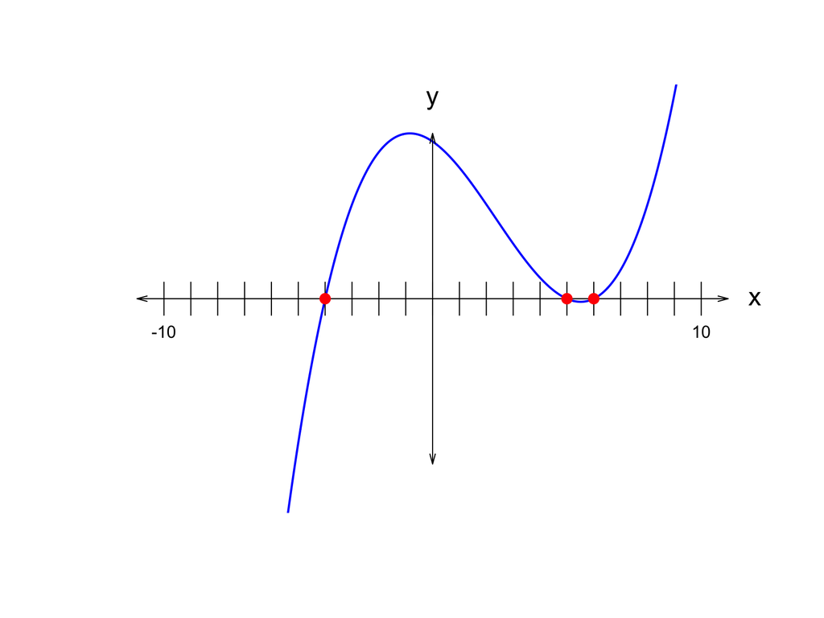

Find $B$, $C$, and $D$.

- $B=$
- $C=$
- $D=$

First, write the cubic polynomial in factored form (based on the three roots).

$$f(x)~=~(x+{4})(x-{5})(x-{6})$$

Partially expand the expression by writing $(x+{4})(x-{5})$ in standard form. To do this, we can use the FOIL method or a box.

| * | $x$ | $4$ |
| --- | --- | --- |
| $x$ | $x^2$ | $4x$ |
| $-5$ | $-5x$ | $-20$ |

$$f(x)~=~
\left(x^{2}-{5}x+{4}x-{20}\right)(x-{6})$$

Combine like terms.

$$f(x)~=~
\left(x^{2}-x-{20}\right)(x-{6})$$

Now, multiply the quadratic by the linear.

| * | $x^2$ | $-1x$ | $-20$ |
| --- | --- | --- | --- |
| $x$ | $x^3$ | $-1x^2$ | $-20x$ |
| $-6$ | $-6x^2$ | $6x$ | $120$ |

$$f(x)~=~x^{3}-{6}x^{2}-x^{2}+{6}x-{20}x+{120}$$

Combine like terms.

$$f(x)~=~x^{3}-{7}x^{2}-{14}x+{120}$$

Thus,

- $B=-7$
- $C=-14$
- $D=120$

A cubic polynomial, $f(x)$, is generated by randomly selecting the three parameters, $B$, $C$, and $D$, in the equation below.

$$f(x)~=~x^3+Bx^2+Cx+D$$

You know the graph $y=f(x)$ has three distinct real roots at $x=-2$, $x=1$, and $x=3$, as shown below.

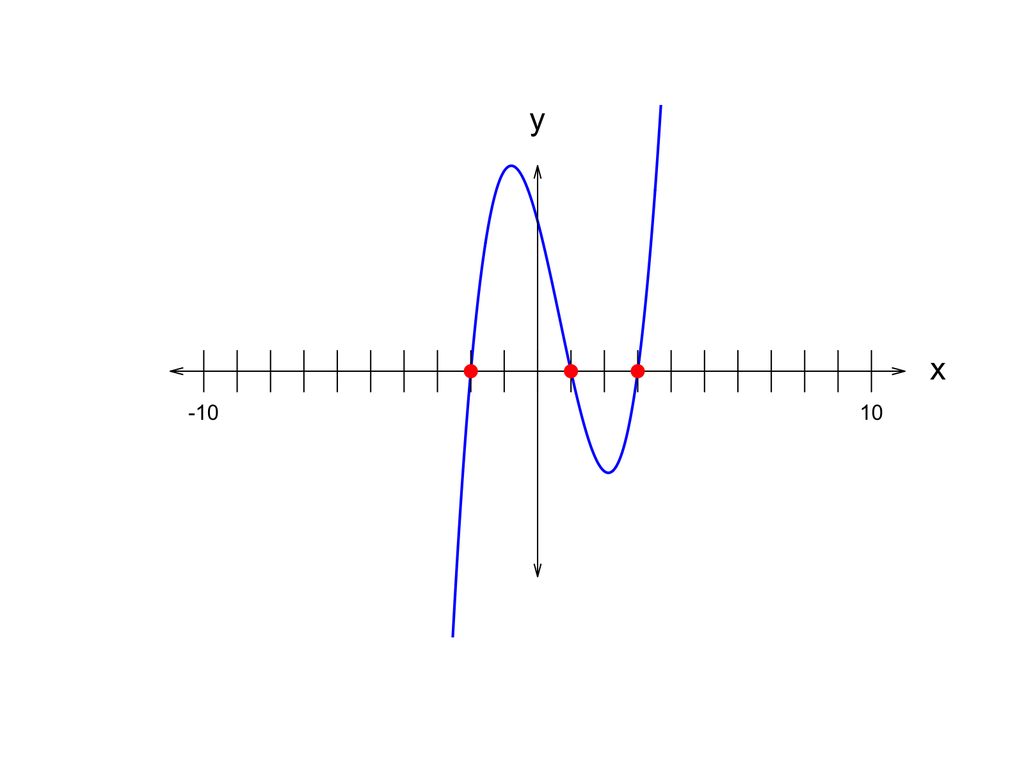

Find $B$, $C$, and $D$.

- $B=$
- $C=$
- $D=$

First, write the cubic polynomial in factored form (based on the three roots).

$$f(x)~=~(x+{2})(x-{1})(x-{3})$$

Partially expand the expression by writing $(x+{2})(x-{1})$ in standard form. To do this, we can use the FOIL method or a box.

| * | $x$ | $2$ |
| --- | --- | --- |
| $x$ | $x^2$ | $2x$ |
| $-1$ | $-1x$ | $-2$ |

$$f(x)~=~
\left(x^{2}-x+{2}x-{2}\right)(x-{3})$$

Combine like terms.

$$f(x)~=~
\left(x^{2}+x-{2}\right)(x-{3})$$

Now, multiply the quadratic by the linear.

| * | $x^2$ | $1x$ | $-2$ |
| --- | --- | --- | --- |
| $x$ | $x^3$ | $1x^2$ | $-2x$ |
| $-3$ | $-3x^2$ | $-3x$ | $6$ |

$$f(x)~=~x^{3}-{3}x^{2}+x^{2}-{3}x-{2}x+{6}$$

Combine like terms.

$$f(x)~=~x^{3}-{2}x^{2}-{5}x+{6}$$

Thus,

- $B=-2$
- $C=-5$
- $D=6$

A cubic polynomial, $f(x)$, is generated by randomly selecting the three parameters, $B$, $C$, and $D$, in the equation below.

$$f(x)~=~x^3+Bx^2+Cx+D$$

You know the graph $y=f(x)$ has three distinct real roots at $x=-6$, $x=1$, and $x=4$, as shown below.

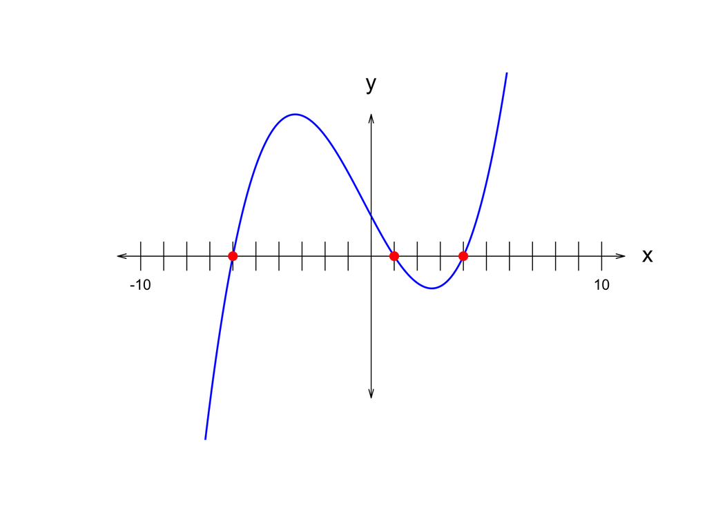

Find $B$, $C$, and $D$.

- $B=$
- $C=$
- $D=$

First, write the cubic polynomial in factored form (based on the three roots).

$$f(x)~=~(x+{6})(x-{1})(x-{4})$$

Partially expand the expression by writing $(x+{6})(x-{1})$ in standard form. To do this, we can use the FOIL method or a box.

| * | $x$ | $6$ |
| --- | --- | --- |
| $x$ | $x^2$ | $6x$ |
| $-1$ | $-1x$ | $-6$ |

$$f(x)~=~
\left(x^{2}-x+{6}x-{6}\right)(x-{4})$$

Combine like terms.

$$f(x)~=~
\left(x^{2}+{5}x-{6}\right)(x-{4})$$

Now, multiply the quadratic by the linear.

| * | $x^2$ | $5x$ | $-6$ |
| --- | --- | --- | --- |
| $x$ | $x^3$ | $5x^2$ | $-6x$ |
| $-4$ | $-4x^2$ | $-20x$ | $24$ |

$$f(x)~=~x^{3}-{4}x^{2}+{5}x^{2}-{20}x-{6}x+{24}$$

Combine like terms.

$$f(x)~=~x^{3}+x^{2}-{26}x+{24}$$

Thus,

- $B=1$
- $C=-26$
- $D=24$

A cubic polynomial, $f(x)$, is generated by randomly selecting the three parameters, $B$, $C$, and $D$, in the equation below.

$$f(x)~=~x^3+Bx^2+Cx+D$$

You know the graph $y=f(x)$ has three distinct real roots at $x=-1$, $x=2$, and $x=3$, as shown below.

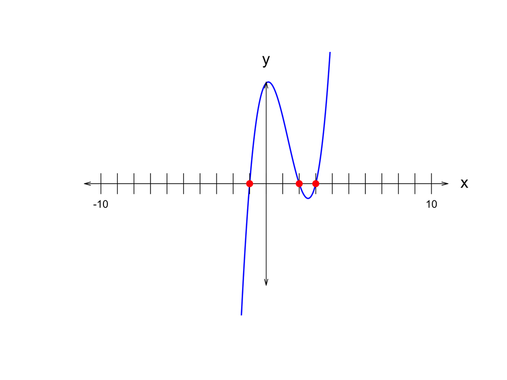

Find $B$, $C$, and $D$.

- $B=$
- $C=$
- $D=$

First, write the cubic polynomial in factored form (based on the three roots).

$$f(x)~=~(x+{1})(x-{2})(x-{3})$$

Partially expand the expression by writing $(x+{1})(x-{2})$ in standard form. To do this, we can use the FOIL method or a box.

| * | $x$ | $1$ |
| --- | --- | --- |
| $x$ | $x^2$ | $1x$ |
| $-2$ | $-2x$ | $-2$ |

$$f(x)~=~
\left(x^{2}-{2}x+x-{2}\right)(x-{3})$$

Combine like terms.

$$f(x)~=~
\left(x^{2}-x-{2}\right)(x-{3})$$

Now, multiply the quadratic by the linear.

| * | $x^2$ | $-1x$ | $-2$ |
| --- | --- | --- | --- |
| $x$ | $x^3$ | $-1x^2$ | $-2x$ |
| $-3$ | $-3x^2$ | $3x$ | $6$ |

$$f(x)~=~x^{3}-{3}x^{2}-x^{2}+{3}x-{2}x+{6}$$

Combine like terms.

$$f(x)~=~x^{3}-{4}x^{2}+x+{6}$$

Thus,

- $B=-4$
- $C=1$
- $D=6$

A cubic polynomial, $f(x)$, is generated by randomly selecting the three parameters, $B$, $C$, and $D$, in the equation below.

$$f(x)~=~x^3+Bx^2+Cx+D$$

You know the graph $y=f(x)$ has three distinct real roots at $x=-1$, $x=5$, and $x=6$, as shown below.

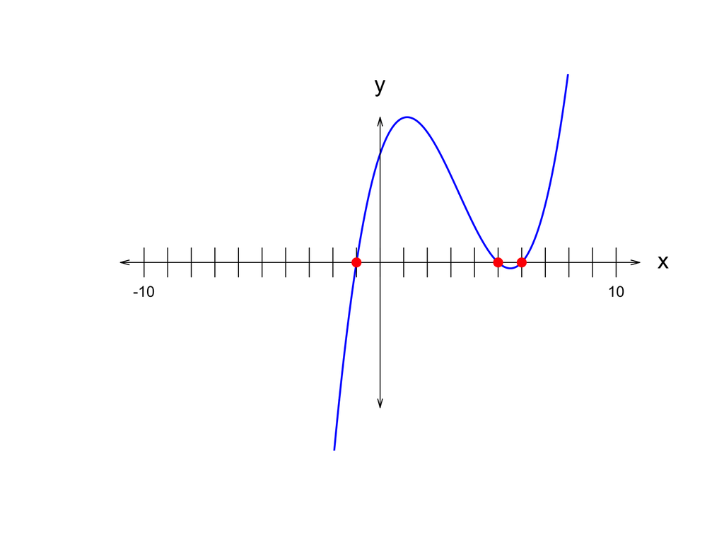

Find $B$, $C$, and $D$.

- $B=$
- $C=$
- $D=$

First, write the cubic polynomial in factored form (based on the three roots).

$$f(x)~=~(x+{1})(x-{5})(x-{6})$$

Partially expand the expression by writing $(x+{1})(x-{5})$ in standard form. To do this, we can use the FOIL method or a box.

| * | $x$ | $1$ |
| --- | --- | --- |
| $x$ | $x^2$ | $1x$ |
| $-5$ | $-5x$ | $-5$ |

$$f(x)~=~
\left(x^{2}-{5}x+x-{5}\right)(x-{6})$$

Combine like terms.

$$f(x)~=~
\left(x^{2}-{4}x-{5}\right)(x-{6})$$

Now, multiply the quadratic by the linear.

| * | $x^2$ | $-4x$ | $-5$ |
| --- | --- | --- | --- |
| $x$ | $x^3$ | $-4x^2$ | $-5x$ |
| $-6$ | $-6x^2$ | $24x$ | $30$ |

$$f(x)~=~x^{3}-{6}x^{2}-{4}x^{2}+{24}x-{5}x+{30}$$

Combine like terms.

$$f(x)~=~x^{3}-{10}x^{2}+{19}x+{30}$$

Thus,

- $B=-10$
- $C=19$
- $D=30$

A cubic polynomial, $f(x)$, is generated by randomly selecting the three parameters, $B$, $C$, and $D$, in the equation below.

$$f(x)~=~x^3+Bx^2+Cx+D$$

You know the graph $y=f(x)$ has three distinct real roots at $x=-5$, $x=-2$, and $x=4$, as shown below.

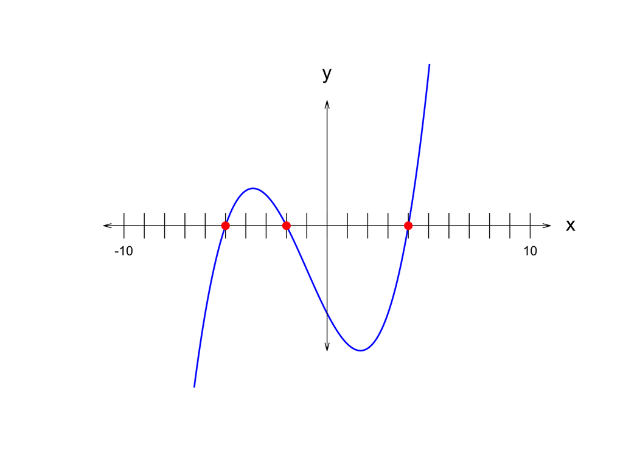

Find $B$, $C$, and $D$.

- $B=$
- $C=$
- $D=$

First, write the cubic polynomial in factored form (based on the three roots).

$$f(x)~=~(x+{5})(x+{2})(x-{4})$$

Partially expand the expression by writing $(x+{5})(x+{2})$ in standard form. To do this, we can use the FOIL method or a box.

| * | $x$ | $5$ |
| --- | --- | --- |
| $x$ | $x^2$ | $5x$ |
| $2$ | $2x$ | $10$ |

$$f(x)~=~
\left(x^{2}+{2}x+{5}x+{10}\right)(x-{4})$$

Combine like terms.

$$f(x)~=~
\left(x^{2}+{7}x+{10}\right)(x-{4})$$

Now, multiply the quadratic by the linear.

| * | $x^2$ | $7x$ | $10$ |
| --- | --- | --- | --- |
| $x$ | $x^3$ | $7x^2$ | $10x$ |
| $-4$ | $-4x^2$ | $-28x$ | $-40$ |

$$f(x)~=~x^{3}-{4}x^{2}+{7}x^{2}-{28}x+{10}x-{40}$$

Combine like terms.

$$f(x)~=~x^{3}+{3}x^{2}-{18}x-{40}$$

Thus,

- $B=3$
- $C=-18$
- $D=-40$

A cubic polynomial, $f(x)$, is generated by randomly selecting the three parameters, $B$, $C$, and $D$, in the equation below.

$$f(x)~=~x^3+Bx^2+Cx+D$$

You know the graph $y=f(x)$ has three distinct real roots at $x=-6$, $x=-5$, and $x=-3$, as shown below.

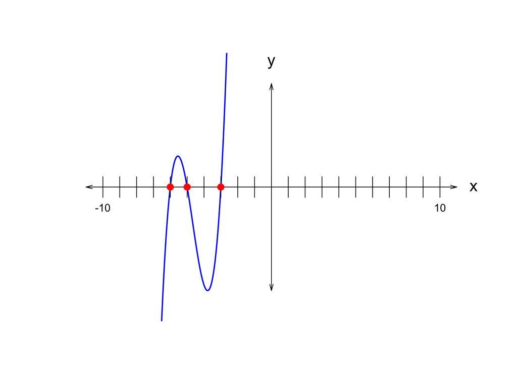

Find $B$, $C$, and $D$.

- $B=$
- $C=$
- $D=$

First, write the cubic polynomial in factored form (based on the three roots).

$$f(x)~=~(x+{6})(x+{5})(x+{3})$$

Partially expand the expression by writing $(x+{6})(x+{5})$ in standard form. To do this, we can use the FOIL method or a box.

| * | $x$ | $6$ |
| --- | --- | --- |
| $x$ | $x^2$ | $6x$ |
| $5$ | $5x$ | $30$ |

$$f(x)~=~
\left(x^{2}+{5}x+{6}x+{30}\right)(x+{3})$$

Combine like terms.

$$f(x)~=~
\left(x^{2}+{11}x+{30}\right)(x+{3})$$

Now, multiply the quadratic by the linear.

| * | $x^2$ | $11x$ | $30$ |
| --- | --- | --- | --- |
| $x$ | $x^3$ | $11x^2$ | $30x$ |
| $3$ | $3x^2$ | $33x$ | $90$ |

$$f(x)~=~x^{3}+{3}x^{2}+{11}x^{2}+{33}x+{30}x+{90}$$

Combine like terms.

$$f(x)~=~x^{3}+{14}x^{2}+{63}x+{90}$$

Thus,

- $B=14$
- $C=63$
- $D=90$

A cubic polynomial, $f(x)$, is generated by randomly selecting the three parameters, $B$, $C$, and $D$, in the equation below.

$$f(x)~=~x^3+Bx^2+Cx+D$$

You know the graph $y=f(x)$ has three distinct real roots at $x=-6$, $x=-4$, and $x=2$, as shown below.

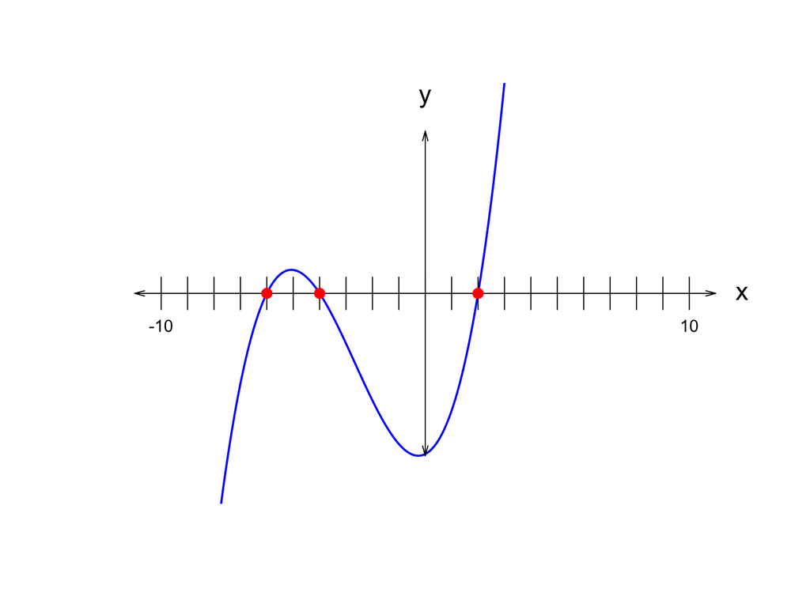

Find $B$, $C$, and $D$.

- $B=$
- $C=$
- $D=$

First, write the cubic polynomial in factored form (based on the three roots).

$$f(x)~=~(x+{6})(x+{4})(x-{2})$$

Partially expand the expression by writing $(x+{6})(x+{4})$ in standard form. To do this, we can use the FOIL method or a box.

| * | $x$ | $6$ |
| --- | --- | --- |
| $x$ | $x^2$ | $6x$ |
| $4$ | $4x$ | $24$ |

$$f(x)~=~
\left(x^{2}+{4}x+{6}x+{24}\right)(x-{2})$$

Combine like terms.

$$f(x)~=~
\left(x^{2}+{10}x+{24}\right)(x-{2})$$

Now, multiply the quadratic by the linear.

| * | $x^2$ | $10x$ | $24$ |
| --- | --- | --- | --- |
| $x$ | $x^3$ | $10x^2$ | $24x$ |
| $-2$ | $-2x^2$ | $-20x$ | $-48$ |

$$f(x)~=~x^{3}-{2}x^{2}+{10}x^{2}-{20}x+{24}x-{48}$$

Combine like terms.

$$f(x)~=~x^{3}+{8}x^{2}+{4}x-{48}$$

Thus,

- $B=8$
- $C=4$
- $D=-48$

A cubic polynomial, $f(x)$, is generated by randomly selecting the three parameters, $B$, $C$, and $D$, in the equation below.

$$f(x)~=~x^3+Bx^2+Cx+D$$

You know the graph $y=f(x)$ has three distinct real roots at $x=-2$, $x=4$, and $x=6$, as shown below.

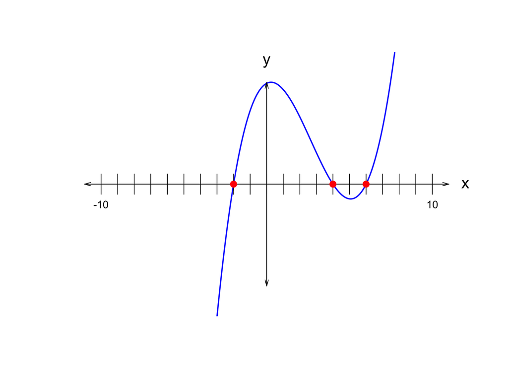

Find $B$, $C$, and $D$.

- $B=$
- $C=$
- $D=$

First, write the cubic polynomial in factored form (based on the three roots).

$$f(x)~=~(x+{2})(x-{4})(x-{6})$$

Partially expand the expression by writing $(x+{2})(x-{4})$ in standard form. To do this, we can use the FOIL method or a box.

| * | $x$ | $2$ |
| --- | --- | --- |
| $x$ | $x^2$ | $2x$ |
| $-4$ | $-4x$ | $-8$ |

$$f(x)~=~
\left(x^{2}-{4}x+{2}x-{8}\right)(x-{6})$$

Combine like terms.

$$f(x)~=~
\left(x^{2}-{2}x-{8}\right)(x-{6})$$

Now, multiply the quadratic by the linear.

| * | $x^2$ | $-2x$ | $-8$ |
| --- | --- | --- | --- |
| $x$ | $x^3$ | $-2x^2$ | $-8x$ |
| $-6$ | $-6x^2$ | $12x$ | $48$ |

$$f(x)~=~x^{3}-{6}x^{2}-{2}x^{2}+{12}x-{8}x+{48}$$

Combine like terms.

$$f(x)~=~x^{3}-{8}x^{2}+{4}x+{48}$$

Thus,

- $B=-8$
- $C=4$
- $D=48$

A cubic polynomial, $f(x)$, is generated by randomly selecting the three parameters, $B$, $C$, and $D$, in the equation below.

$$f(x)~=~x^3+Bx^2+Cx+D$$

You know the graph $y=f(x)$ has three distinct real roots at $x=1$, $x=4$, and $x=6$, as shown below.

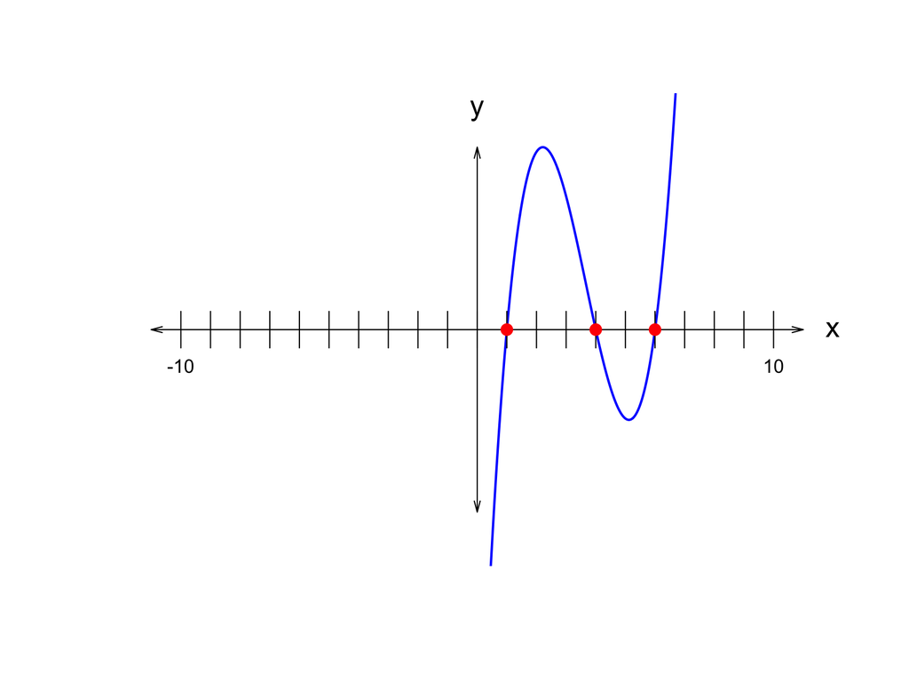

Find $B$, $C$, and $D$.

- $B=$
- $C=$
- $D=$

First, write the cubic polynomial in factored form (based on the three roots).

$$f(x)~=~(x-{1})(x-{4})(x-{6})$$

Partially expand the expression by writing $(x-{1})(x-{4})$ in standard form. To do this, we can use the FOIL method or a box.

| * | $x$ | $-1$ |
| --- | --- | --- |
| $x$ | $x^2$ | $-1x$ |
| $-4$ | $-4x$ | $4$ |

$$f(x)~=~
\left(x^{2}-{4}x-x+{4}\right)(x-{6})$$

Combine like terms.

$$f(x)~=~
\left(x^{2}-{5}x+{4}\right)(x-{6})$$

Now, multiply the quadratic by the linear.

| * | $x^2$ | $-5x$ | $4$ |
| --- | --- | --- | --- |
| $x$ | $x^3$ | $-5x^2$ | $4x$ |
| $-6$ | $-6x^2$ | $30x$ | $-24$ |

$$f(x)~=~x^{3}-{6}x^{2}-{5}x^{2}+{30}x+{4}x-{24}$$

Combine like terms.

$$f(x)~=~x^{3}-{11}x^{2}+{34}x-{24}$$

Thus,

- $B=-11$
- $C=34$
- $D=-24$

A cubic polynomial, $f(x)$, is generated by randomly selecting the three parameters, $B$, $C$, and $D$, in the equation below.

$$f(x)~=~x^3+Bx^2+Cx+D$$

You know the graph $y=f(x)$ has two distinct real roots at $x=2$ and $x=4$, as shown below. Also, since the curve "bounces" at $x=2$, we say that root has multiplicity of 2.

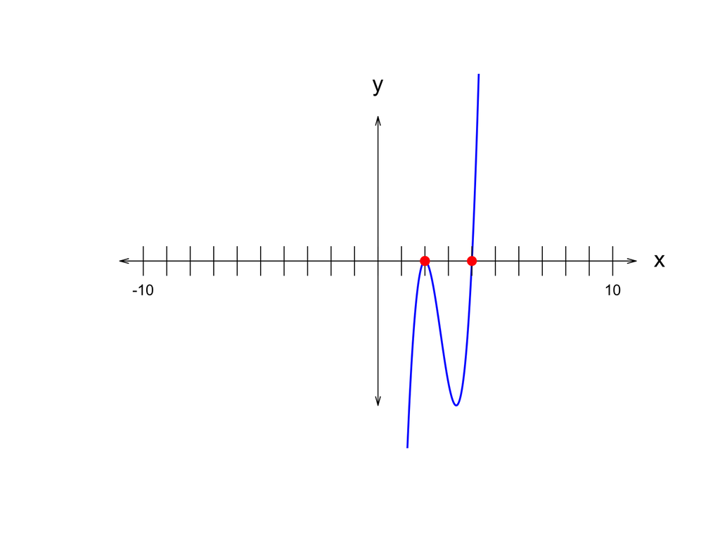

Find $B$, $C$, and $D$.

- $B=$
- $C=$
- $D=$

First, write the cubic polynomial in factored form (based on the three roots).

$$f(x)~=~(x-{2})(x-{2})(x-{4})$$

Partially expand the expression by writing $(x-{2})(x-{2})$ in standard form. To do this, we can use the FOIL method or a box.

| * | $x$ | $-2$ |
| --- | --- | --- |
| $x$ | $x^2$ | $-2x$ |
| $-2$ | $-2x$ | $4$ |

$$f(x)~=~
\left(x^{2}-{2}x-{2}x+{4}\right)(x-{4})$$

Combine like terms.

$$f(x)~=~
\left(x^{2}-{4}x+{4}\right)(x-{4})$$

Now, multiply the quadratic by the linear.

| * | $x^2$ | $-4x$ | $4$ |
| --- | --- | --- | --- |
| $x$ | $x^3$ | $-4x^2$ | $4x$ |
| $-4$ | $-4x^2$ | $16x$ | $-16$ |

$$f(x)~=~x^{3}-{4}x^{2}-{4}x^{2}+{16}x+{4}x-{16}$$

Combine like terms.

$$f(x)~=~x^{3}-{8}x^{2}+{20}x-{16}$$

Thus,

- $B=-8$
- $C=20$
- $D=-16$

A cubic polynomial, $f(x)$, is generated by randomly selecting the three parameters, $B$, $C$, and $D$, in the equation below.

$$f(x)~=~x^3+Bx^2+Cx+D$$

You know the graph $y=f(x)$ has two distinct real roots at $x=1$ and $x=4$, as shown below. Also, since the curve "bounces" at $x=4$, we say that root has multiplicity of 2.

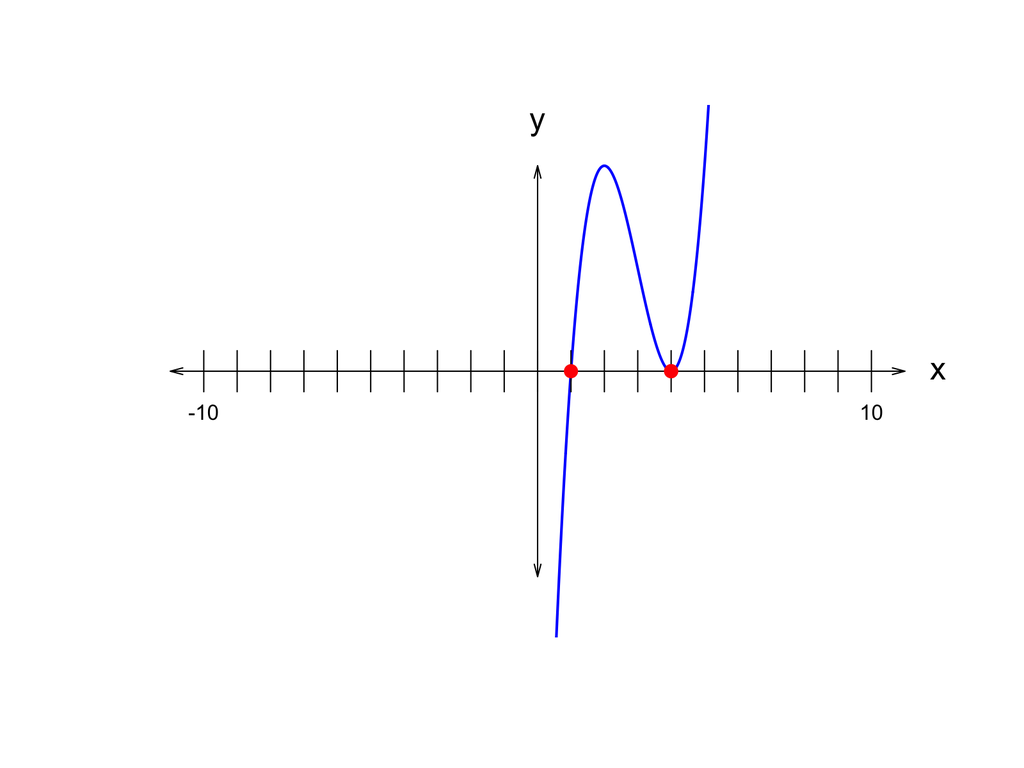

Find $B$, $C$, and $D$.

- $B=$
- $C=$
- $D=$

First, write the cubic polynomial in factored form (based on the three roots).

$$f(x)~=~(x-{1})(x-{4})(x-{4})$$

Partially expand the expression by writing $(x-{1})(x-{4})$ in standard form. To do this, we can use the FOIL method or a box.

| * | $x$ | $-1$ |
| --- | --- | --- |
| $x$ | $x^2$ | $-1x$ |
| $-4$ | $-4x$ | $4$ |

$$f(x)~=~
\left(x^{2}-{4}x-x+{4}\right)(x-{4})$$

Combine like terms.

$$f(x)~=~
\left(x^{2}-{5}x+{4}\right)(x-{4})$$

Now, multiply the quadratic by the linear.

| * | $x^2$ | $-5x$ | $4$ |
| --- | --- | --- | --- |
| $x$ | $x^3$ | $-5x^2$ | $4x$ |
| $-4$ | $-4x^2$ | $20x$ | $-16$ |

$$f(x)~=~x^{3}-{4}x^{2}-{5}x^{2}+{20}x+{4}x-{16}$$

Combine like terms.

$$f(x)~=~x^{3}-{9}x^{2}+{24}x-{16}$$

Thus,

- $B=-9$
- $C=24$
- $D=-16$

A cubic polynomial, $f(x)$, is generated by randomly selecting the three parameters, $B$, $C$, and $D$, in the equation below.

$$f(x)~=~x^3+Bx^2+Cx+D$$

You know the graph $y=f(x)$ has two distinct real roots at $x=-5$ and $x=3$, as shown below. Also, since the curve "bounces" at $x=3$, we say that root has multiplicity of 2.

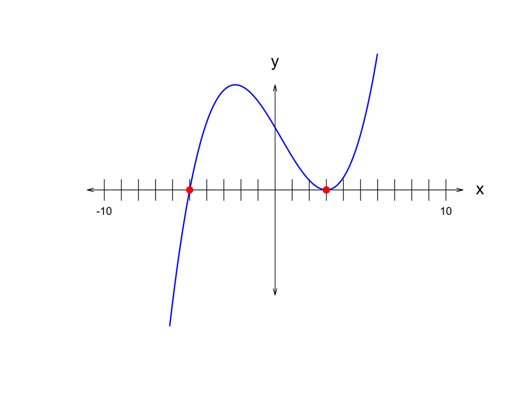

Find $B$, $C$, and $D$.

- $B=$
- $C=$
- $D=$

First, write the cubic polynomial in factored form (based on the three roots).

$$f(x)~=~(x+{5})(x-{3})(x-{3})$$

Partially expand the expression by writing $(x+{5})(x-{3})$ in standard form. To do this, we can use the FOIL method or a box.

| * | $x$ | $5$ |
| --- | --- | --- |
| $x$ | $x^2$ | $5x$ |
| $-3$ | $-3x$ | $-15$ |

$$f(x)~=~
\left(x^{2}-{3}x+{5}x-{15}\right)(x-{3})$$

Combine like terms.

$$f(x)~=~
\left(x^{2}+{2}x-{15}\right)(x-{3})$$

Now, multiply the quadratic by the linear.

| * | $x^2$ | $2x$ | $-15$ |
| --- | --- | --- | --- |
| $x$ | $x^3$ | $2x^2$ | $-15x$ |
| $-3$ | $-3x^2$ | $-6x$ | $45$ |

$$f(x)~=~x^{3}-{3}x^{2}+{2}x^{2}-{6}x-{15}x+{45}$$

Combine like terms.

$$f(x)~=~x^{3}-x^{2}-{21}x+{45}$$

Thus,

- $B=-1$
- $C=-21$
- $D=45$

A cubic polynomial, $f(x)$, is generated by randomly selecting the three parameters, $B$, $C$, and $D$, in the equation below.

$$f(x)~=~x^3+Bx^2+Cx+D$$

You know the graph $y=f(x)$ has two distinct real roots at $x=-2$ and $x=3$, as shown below. Also, since the curve "bounces" at $x=3$, we say that root has multiplicity of 2.

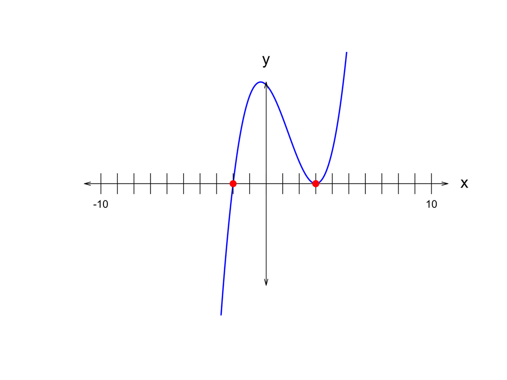

Find $B$, $C$, and $D$.

- $B=$
- $C=$
- $D=$

First, write the cubic polynomial in factored form (based on the three roots).

$$f(x)~=~(x+{2})(x-{3})(x-{3})$$

Partially expand the expression by writing $(x+{2})(x-{3})$ in standard form. To do this, we can use the FOIL method or a box.

| * | $x$ | $2$ |
| --- | --- | --- |
| $x$ | $x^2$ | $2x$ |
| $-3$ | $-3x$ | $-6$ |

$$f(x)~=~
\left(x^{2}-{3}x+{2}x-{6}\right)(x-{3})$$

Combine like terms.

$$f(x)~=~
\left(x^{2}-x-{6}\right)(x-{3})$$

Now, multiply the quadratic by the linear.

| * | $x^2$ | $-1x$ | $-6$ |
| --- | --- | --- | --- |
| $x$ | $x^3$ | $-1x^2$ | $-6x$ |
| $-3$ | $-3x^2$ | $3x$ | $18$ |

$$f(x)~=~x^{3}-{3}x^{2}-x^{2}+{3}x-{6}x+{18}$$

Combine like terms.

$$f(x)~=~x^{3}-{4}x^{2}-{3}x+{18}$$

Thus,

- $B=-4$
- $C=-3$
- $D=18$

A cubic polynomial, $f(x)$, is generated by randomly selecting the three parameters, $B$, $C$, and $D$, in the equation below.

$$f(x)~=~x^3+Bx^2+Cx+D$$

You know the graph $y=f(x)$ has two distinct real roots at $x=-5$ and $x=4$, as shown below. Also, since the curve "bounces" at $x=4$, we say that root has multiplicity of 2.

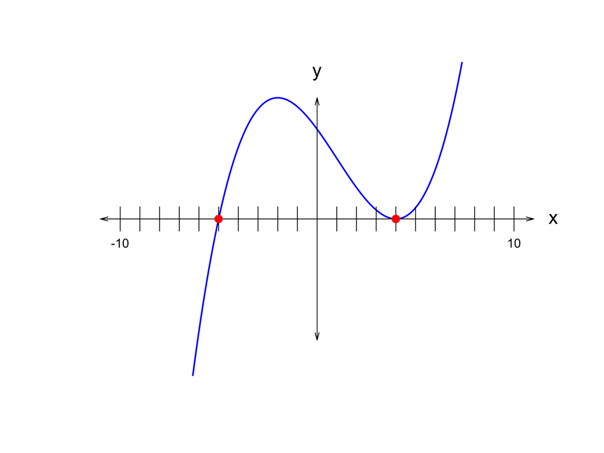

Find $B$, $C$, and $D$.

- $B=$
- $C=$
- $D=$

First, write the cubic polynomial in factored form (based on the three roots).

$$f(x)~=~(x+{5})(x-{4})(x-{4})$$

Partially expand the expression by writing $(x+{5})(x-{4})$ in standard form. To do this, we can use the FOIL method or a box.

| * | $x$ | $5$ |
| --- | --- | --- |
| $x$ | $x^2$ | $5x$ |
| $-4$ | $-4x$ | $-20$ |

$$f(x)~=~
\left(x^{2}-{4}x+{5}x-{20}\right)(x-{4})$$

Combine like terms.

$$f(x)~=~
\left(x^{2}+x-{20}\right)(x-{4})$$

Now, multiply the quadratic by the linear.

| * | $x^2$ | $1x$ | $-20$ |
| --- | --- | --- | --- |
| $x$ | $x^3$ | $1x^2$ | $-20x$ |
| $-4$ | $-4x^2$ | $-4x$ | $80$ |

$$f(x)~=~x^{3}-{4}x^{2}+x^{2}-{4}x-{20}x+{80}$$

Combine like terms.

$$f(x)~=~x^{3}-{3}x^{2}-{24}x+{80}$$

Thus,

- $B=-3$
- $C=-24$
- $D=80$

A cubic polynomial, $f(x)$, is generated by randomly selecting the three parameters, $B$, $C$, and $D$, in the equation below.

$$f(x)~=~x^3+Bx^2+Cx+D$$

You know the graph $y=f(x)$ has two distinct real roots at $x=-1$ and $x=6$, as shown below. Also, since the curve "bounces" at $x=6$, we say that root has multiplicity of 2.

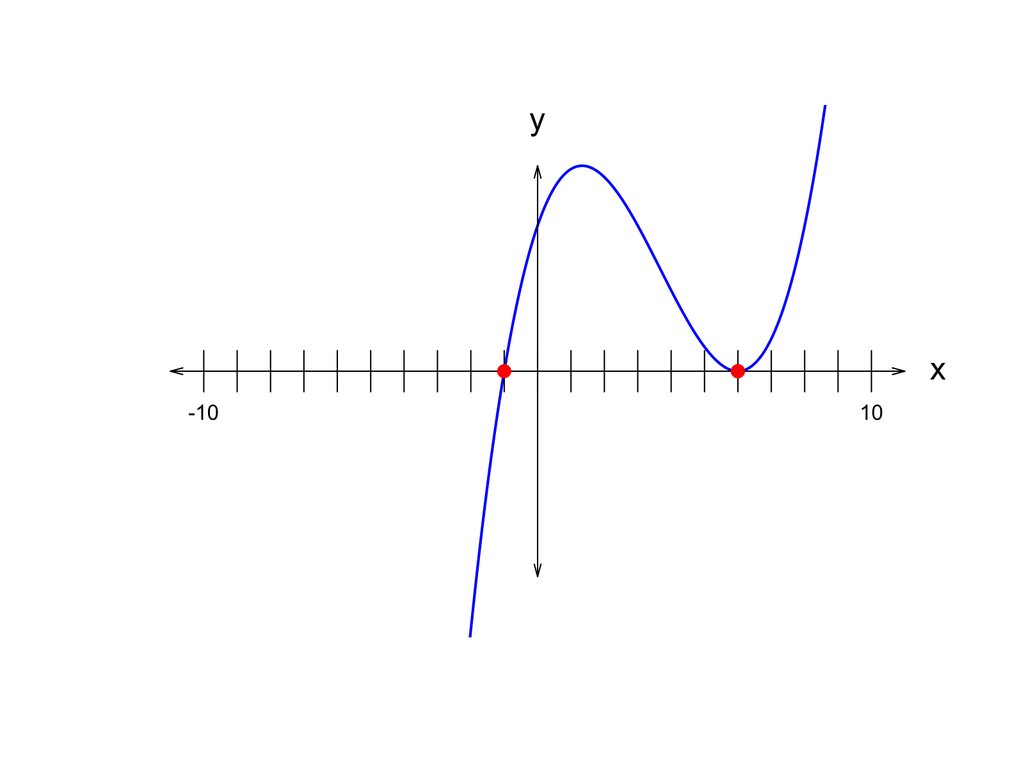

Find $B$, $C$, and $D$.

- $B=$
- $C=$
- $D=$

First, write the cubic polynomial in factored form (based on the three roots).

$$f(x)~=~(x+{1})(x-{6})(x-{6})$$

Partially expand the expression by writing $(x+{1})(x-{6})$ in standard form. To do this, we can use the FOIL method or a box.

| * | $x$ | $1$ |
| --- | --- | --- |
| $x$ | $x^2$ | $1x$ |
| $-6$ | $-6x$ | $-6$ |

$$f(x)~=~
\left(x^{2}-{6}x+x-{6}\right)(x-{6})$$

Combine like terms.

$$f(x)~=~
\left(x^{2}-{5}x-{6}\right)(x-{6})$$

Now, multiply the quadratic by the linear.

| * | $x^2$ | $-5x$ | $-6$ |
| --- | --- | --- | --- |
| $x$ | $x^3$ | $-5x^2$ | $-6x$ |
| $-6$ | $-6x^2$ | $30x$ | $36$ |

$$f(x)~=~x^{3}-{6}x^{2}-{5}x^{2}+{30}x-{6}x+{36}$$

Combine like terms.

$$f(x)~=~x^{3}-{11}x^{2}+{24}x+{36}$$

Thus,

- $B=-11$
- $C=24$
- $D=36$

A cubic polynomial, $f(x)$, is generated by randomly selecting the three parameters, $B$, $C$, and $D$, in the equation below.

$$f(x)~=~x^3+Bx^2+Cx+D$$

You know the graph $y=f(x)$ has two distinct real roots at $x=-5$ and $x=-4$, as shown below. Also, since the curve "bounces" at $x=-4$, we say that root has multiplicity of 2.

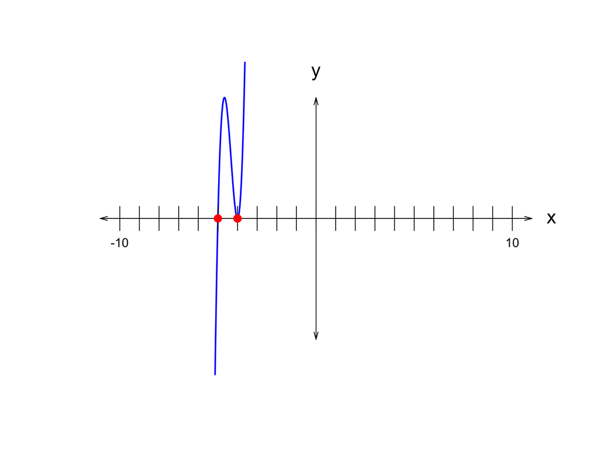

Find $B$, $C$, and $D$.

- $B=$
- $C=$
- $D=$

First, write the cubic polynomial in factored form (based on the three roots).

$$f(x)~=~(x+{5})(x+{4})(x+{4})$$

Partially expand the expression by writing $(x+{5})(x+{4})$ in standard form. To do this, we can use the FOIL method or a box.

| * | $x$ | $5$ |
| --- | --- | --- |
| $x$ | $x^2$ | $5x$ |
| $4$ | $4x$ | $20$ |

$$f(x)~=~
\left(x^{2}+{4}x+{5}x+{20}\right)(x+{4})$$

Combine like terms.

$$f(x)~=~
\left(x^{2}+{9}x+{20}\right)(x+{4})$$

Now, multiply the quadratic by the linear.

| * | $x^2$ | $9x$ | $20$ |
| --- | --- | --- | --- |
| $x$ | $x^3$ | $9x^2$ | $20x$ |
| $4$ | $4x^2$ | $36x$ | $80$ |

$$f(x)~=~x^{3}+{4}x^{2}+{9}x^{2}+{36}x+{20}x+{80}$$

Combine like terms.

$$f(x)~=~x^{3}+{13}x^{2}+{56}x+{80}$$

Thus,

- $B=13$
- $C=56$
- $D=80$

A cubic polynomial, $f(x)$, is generated by randomly selecting the three parameters, $B$, $C$, and $D$, in the equation below.

$$f(x)~=~x^3+Bx^2+Cx+D$$

You know the graph $y=f(x)$ has two distinct real roots at $x=-6$ and $x=6$, as shown below. Also, since the curve "bounces" at $x=6$, we say that root has multiplicity of 2.

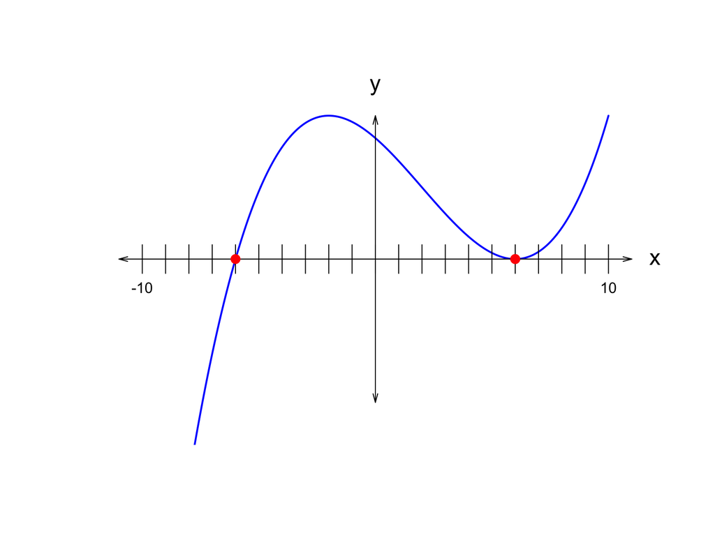

Find $B$, $C$, and $D$.

- $B=$
- $C=$
- $D=$

First, write the cubic polynomial in factored form (based on the three roots).

$$f(x)~=~(x+{6})(x-{6})(x-{6})$$

Partially expand the expression by writing $(x+{6})(x-{6})$ in standard form. To do this, we can use the FOIL method or a box.

| * | $x$ | $6$ |
| --- | --- | --- |
| $x$ | $x^2$ | $6x$ |
| $-6$ | $-6x$ | $-36$ |

$$f(x)~=~
\left(x^{2}-{6}x+{6}x-{36}\right)(x-{6})$$

Combine like terms.

$$f(x)~=~
\left(x^{2}-{36}\right)(x-{6})$$

Now, multiply the quadratic by the linear.

| * | $x^2$ | $0x$ | $-36$ |
| --- | --- | --- | --- |
| $x$ | $x^3$ | $0x^2$ | $-36x$ |
| $-6$ | $-6x^2$ | $0x$ | $216$ |

$$f(x)~=~x^{3}-{6}x^{2}-{36}x+{216}$$

Combine like terms.

$$f(x)~=~x^{3}-{6}x^{2}-{36}x+{216}$$

Thus,

- $B=-6$
- $C=-36$
- $D=216$

A cubic polynomial, $f(x)$, is generated by randomly selecting the three parameters, $B$, $C$, and $D$, in the equation below.

$$f(x)~=~x^3+Bx^2+Cx+D$$

You know the graph $y=f(x)$ has two distinct real roots at $x=-1$ and $x=6$, as shown below. Also, since the curve "bounces" at $x=-1$, we say that root has multiplicity of 2.

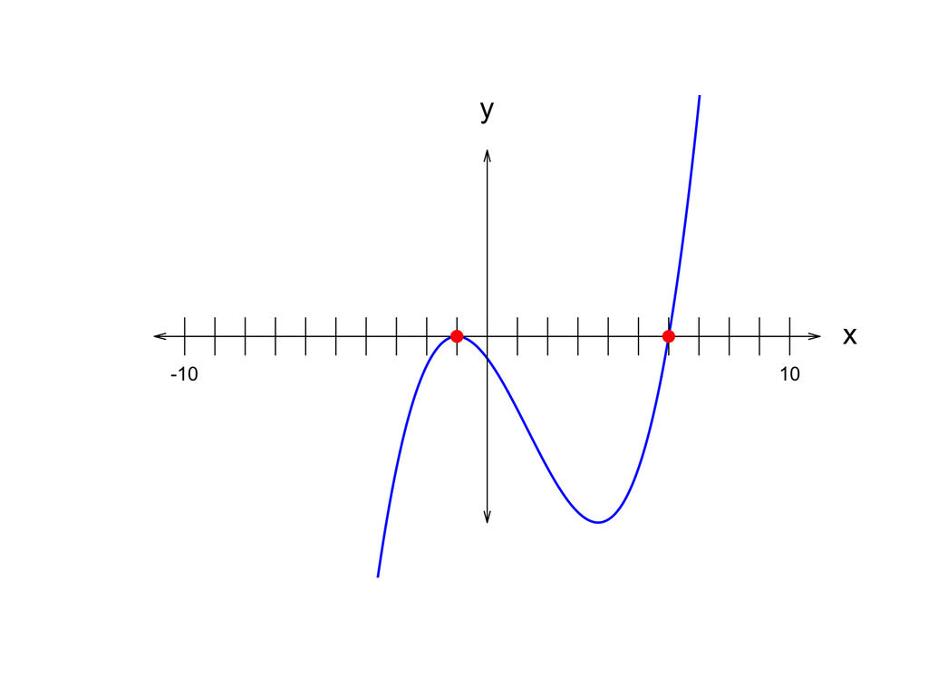

Find $B$, $C$, and $D$.

- $B=$
- $C=$
- $D=$

First, write the cubic polynomial in factored form (based on the three roots).

$$f(x)~=~(x+{1})(x+{1})(x-{6})$$

Partially expand the expression by writing $(x+{1})(x+{1})$ in standard form. To do this, we can use the FOIL method or a box.

| * | $x$ | $1$ |
| --- | --- | --- |
| $x$ | $x^2$ | $1x$ |
| $1$ | $1x$ | $1$ |

$$f(x)~=~
\left(x^{2}+x+x+{1}\right)(x-{6})$$

Combine like terms.

$$f(x)~=~
\left(x^{2}+{2}x+{1}\right)(x-{6})$$

Now, multiply the quadratic by the linear.

| * | $x^2$ | $2x$ | $1$ |
| --- | --- | --- | --- |
| $x$ | $x^3$ | $2x^2$ | $1x$ |
| $-6$ | $-6x^2$ | $-12x$ | $-6$ |

$$f(x)~=~x^{3}-{6}x^{2}+{2}x^{2}-{12}x+x-{6}$$

Combine like terms.

$$f(x)~=~x^{3}-{4}x^{2}-{11}x-{6}$$

Thus,

- $B=-4$
- $C=-11$
- $D=-6$

A cubic polynomial, $f(x)$, is generated by randomly selecting the three parameters, $B$, $C$, and $D$, in the equation below.

$$f(x)~=~x^3+Bx^2+Cx+D$$

You know the graph $y=f(x)$ has two distinct real roots at $x=-2$ and $x=1$, as shown below. Also, since the curve "bounces" at $x=1$, we say that root has multiplicity of 2.

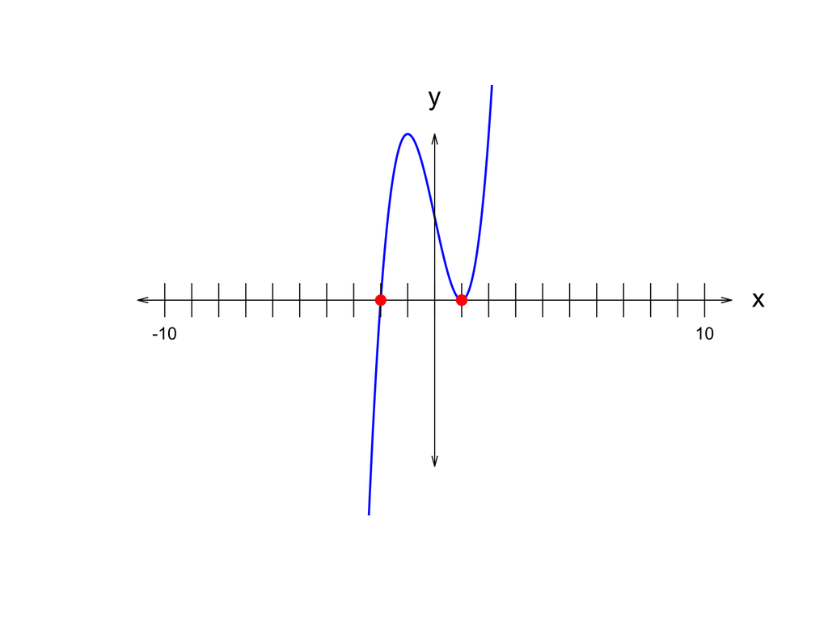

Find $B$, $C$, and $D$.

- $B=$
- $C=$
- $D=$

First, write the cubic polynomial in factored form (based on the three roots).

$$f(x)~=~(x+{2})(x-{1})(x-{1})$$

Partially expand the expression by writing $(x+{2})(x-{1})$ in standard form. To do this, we can use the FOIL method or a box.

| * | $x$ | $2$ |
| --- | --- | --- |
| $x$ | $x^2$ | $2x$ |
| $-1$ | $-1x$ | $-2$ |

$$f(x)~=~
\left(x^{2}-x+{2}x-{2}\right)(x-{1})$$

Combine like terms.

$$f(x)~=~
\left(x^{2}+x-{2}\right)(x-{1})$$

Now, multiply the quadratic by the linear.

| * | $x^2$ | $1x$ | $-2$ |
| --- | --- | --- | --- |
| $x$ | $x^3$ | $1x^2$ | $-2x$ |
| $-1$ | $-1x^2$ | $-1x$ | $2$ |

$$f(x)~=~x^{3}-x^{2}+x^{2}-x-{2}x+{2}$$

Combine like terms.

$$f(x)~=~x^{3}-{3}x+{2}$$

Thus,

- $B=0$
- $C=-3$
- $D=2$

A cubic polynomial, $f(x)$, is generated by randomly selecting the three parameters, $B$, $C$, and $D$, in the equation below.

$$f(x)~=~x^3+Bx^2+Cx+D$$

You know the graph $y=f(x)$ has one distinct real root at $x=2$. You could predict (due to the [inflection point](https://en.wikipedia.org/wiki/Inflection_point)), that the root at $x=2$ has multiplicity 3. Indeed, in this case, the multiplicity of the root is 3.

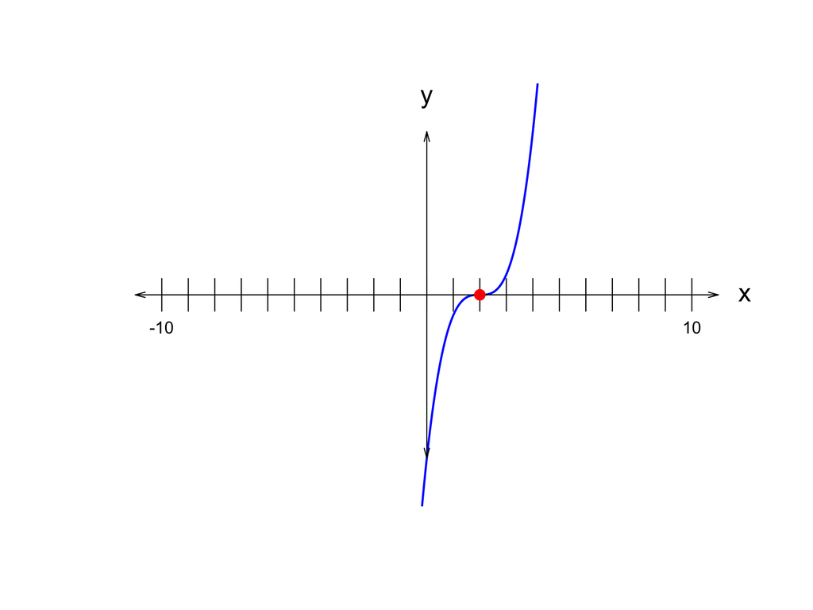

Find $B$, $C$, and $D$.

- $B=$
- $C=$
- $D=$

First, write the cubic polynomial in factored form (based on the three roots).

$$f(x)~=~(x-{2})(x-{2})(x-{2})$$

Partially expand the expression by writing $(x-{2})(x-{2})$ in standard form. To do this, we can use the FOIL method or a box.

| * | $x$ | $-2$ |
| --- | --- | --- |
| $x$ | $x^2$ | $-2x$ |
| $-2$ | $-2x$ | $4$ |

$$f(x)~=~
\left(x^{2}-{2}x-{2}x+{4}\right)(x-{2})$$

Combine like terms.

$$f(x)~=~
\left(x^{2}-{4}x+{4}\right)(x-{2})$$

Now, multiply the quadratic by the linear.

| * | $x^2$ | $-4x$ | $4$ |
| --- | --- | --- | --- |
| $x$ | $x^3$ | $-4x^2$ | $4x$ |
| $-2$ | $-2x^2$ | $8x$ | $-8$ |

$$f(x)~=~x^{3}-{2}x^{2}-{4}x^{2}+{8}x+{4}x-{8}$$

Combine like terms.

$$f(x)~=~x^{3}-{6}x^{2}+{12}x-{8}$$

Thus,

- $B=-6$
- $C=12$
- $D=-8$

A cubic polynomial, $f(x)$, is generated by randomly selecting the three parameters, $B$, $C$, and $D$, in the equation below.

$$f(x)~=~x^3+Bx^2+Cx+D$$

You know the graph $y=f(x)$ has one distinct real root at $x=1$. You could predict (due to the [inflection point](https://en.wikipedia.org/wiki/Inflection_point)), that the root at $x=1$ has multiplicity 3. Indeed, in this case, the multiplicity of the root is 3.

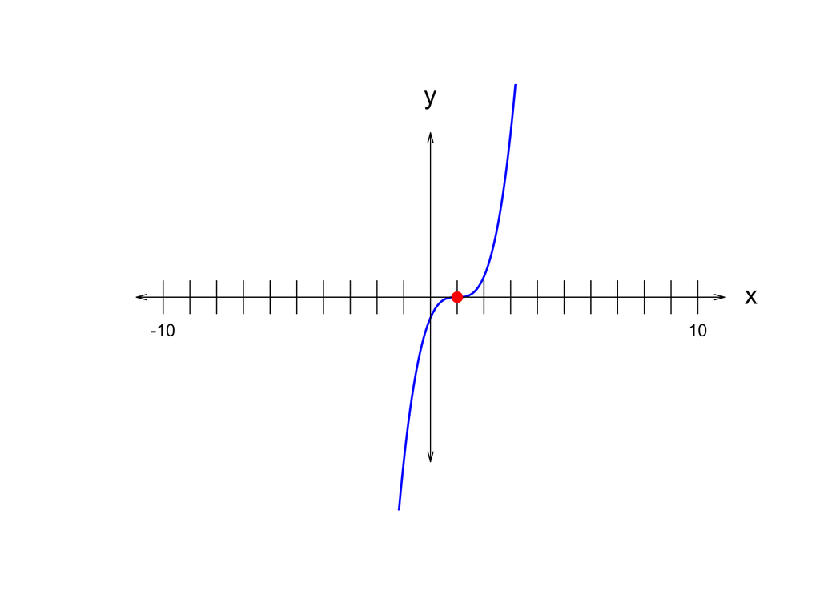

Find $B$, $C$, and $D$.

- $B=$
- $C=$
- $D=$

First, write the cubic polynomial in factored form (based on the three roots).

$$f(x)~=~(x-{1})(x-{1})(x-{1})$$

Partially expand the expression by writing $(x-{1})(x-{1})$ in standard form. To do this, we can use the FOIL method or a box.

| * | $x$ | $-1$ |
| --- | --- | --- |
| $x$ | $x^2$ | $-1x$ |
| $-1$ | $-1x$ | $1$ |

$$f(x)~=~
\left(x^{2}-x-x+{1}\right)(x-{1})$$

Combine like terms.

$$f(x)~=~
\left(x^{2}-{2}x+{1}\right)(x-{1})$$

Now, multiply the quadratic by the linear.

| * | $x^2$ | $-2x$ | $1$ |
| --- | --- | --- | --- |
| $x$ | $x^3$ | $-2x^2$ | $1x$ |
| $-1$ | $-1x^2$ | $2x$ | $-1$ |

$$f(x)~=~x^{3}-x^{2}-{2}x^{2}+{2}x+x-{1}$$

Combine like terms.

$$f(x)~=~x^{3}-{3}x^{2}+{3}x-{1}$$

Thus,

- $B=-3$
- $C=3$
- $D=-1$

A cubic polynomial, $f(x)$, is generated by randomly selecting the three parameters, $B$, $C$, and $D$, in the equation below.

$$f(x)~=~x^3+Bx^2+Cx+D$$

You know the graph $y=f(x)$ has one distinct real root at $x=-4$. You could predict (due to the [inflection point](https://en.wikipedia.org/wiki/Inflection_point)), that the root at $x=-4$ has multiplicity 3. Indeed, in this case, the multiplicity of the root is 3.

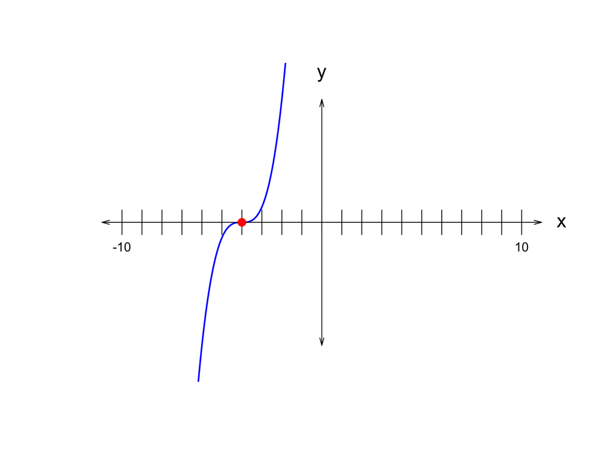

Find $B$, $C$, and $D$.

- $B=$
- $C=$
- $D=$

First, write the cubic polynomial in factored form (based on the three roots).

$$f(x)~=~(x+{4})(x+{4})(x+{4})$$

Partially expand the expression by writing $(x+{4})(x+{4})$ in standard form. To do this, we can use the FOIL method or a box.

| * | $x$ | $4$ |
| --- | --- | --- |
| $x$ | $x^2$ | $4x$ |
| $4$ | $4x$ | $16$ |

$$f(x)~=~
\left(x^{2}+{4}x+{4}x+{16}\right)(x+{4})$$

Combine like terms.

$$f(x)~=~
\left(x^{2}+{8}x+{16}\right)(x+{4})$$

Now, multiply the quadratic by the linear.

| * | $x^2$ | $8x$ | $16$ |
| --- | --- | --- | --- |
| $x$ | $x^3$ | $8x^2$ | $16x$ |
| $4$ | $4x^2$ | $32x$ | $64$ |

$$f(x)~=~x^{3}+{4}x^{2}+{8}x^{2}+{32}x+{16}x+{64}$$

Combine like terms.

$$f(x)~=~x^{3}+{12}x^{2}+{48}x+{64}$$

Thus,

- $B=12$
- $C=48$
- $D=64$

A cubic polynomial, $f(x)$, is generated by randomly selecting the three parameters, $B$, $C$, and $D$, in the equation below.

$$f(x)~=~x^3+Bx^2+Cx+D$$

You know the graph $y=f(x)$ has one distinct real root at $x=-5$. You could predict (due to the [inflection point](https://en.wikipedia.org/wiki/Inflection_point)), that the root at $x=-5$ has multiplicity 3. Indeed, in this case, the multiplicity of the root is 3.

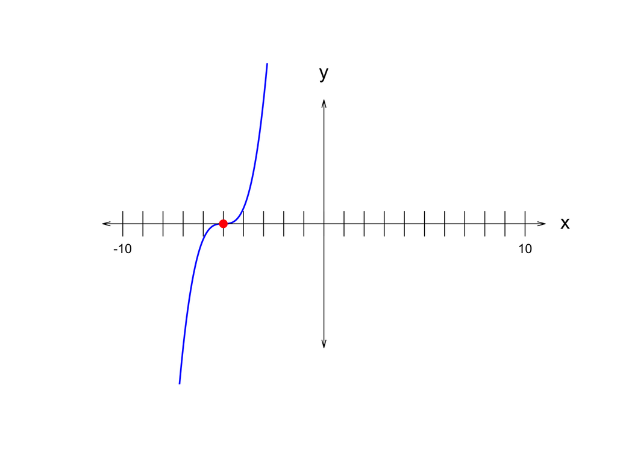

Find $B$, $C$, and $D$.

- $B=$
- $C=$
- $D=$

First, write the cubic polynomial in factored form (based on the three roots).

$$f(x)~=~(x+{5})(x+{5})(x+{5})$$

Partially expand the expression by writing $(x+{5})(x+{5})$ in standard form. To do this, we can use the FOIL method or a box.

| * | $x$ | $5$ |
| --- | --- | --- |
| $x$ | $x^2$ | $5x$ |
| $5$ | $5x$ | $25$ |

$$f(x)~=~
\left(x^{2}+{5}x+{5}x+{25}\right)(x+{5})$$

Combine like terms.

$$f(x)~=~
\left(x^{2}+{10}x+{25}\right)(x+{5})$$

Now, multiply the quadratic by the linear.

| * | $x^2$ | $10x$ | $25$ |
| --- | --- | --- | --- |
| $x$ | $x^3$ | $10x^2$ | $25x$ |
| $5$ | $5x^2$ | $50x$ | $125$ |

$$f(x)~=~x^{3}+{5}x^{2}+{10}x^{2}+{50}x+{25}x+{125}$$

Combine like terms.

$$f(x)~=~x^{3}+{15}x^{2}+{75}x+{125}$$

Thus,

- $B=15$
- $C=75$
- $D=125$

A cubic polynomial, $f(x)$, is generated by randomly selecting the three parameters, $B$, $C$, and $D$, in the equation below.

$$f(x)~=~x^3+Bx^2+Cx+D$$

You know the graph $y=f(x)$ has one distinct real root at $x=1$. You could predict (due to the [inflection point](https://en.wikipedia.org/wiki/Inflection_point)), that the root at $x=1$ has multiplicity 3. Indeed, in this case, the multiplicity of the root is 3.

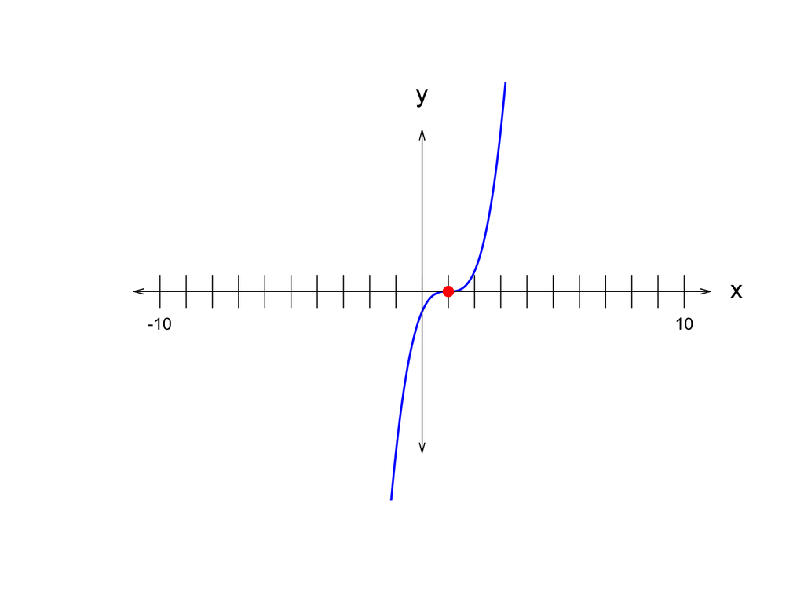

Find $B$, $C$, and $D$.

- $B=$
- $C=$
- $D=$

First, write the cubic polynomial in factored form (based on the three roots).

$$f(x)~=~(x-{1})(x-{1})(x-{1})$$

Partially expand the expression by writing $(x-{1})(x-{1})$ in standard form. To do this, we can use the FOIL method or a box.

| * | $x$ | $-1$ |
| --- | --- | --- |
| $x$ | $x^2$ | $-1x$ |
| $-1$ | $-1x$ | $1$ |

$$f(x)~=~
\left(x^{2}-x-x+{1}\right)(x-{1})$$

Combine like terms.

$$f(x)~=~
\left(x^{2}-{2}x+{1}\right)(x-{1})$$

Now, multiply the quadratic by the linear.

| * | $x^2$ | $-2x$ | $1$ |
| --- | --- | --- | --- |
| $x$ | $x^3$ | $-2x^2$ | $1x$ |
| $-1$ | $-1x^2$ | $2x$ | $-1$ |

$$f(x)~=~x^{3}-x^{2}-{2}x^{2}+{2}x+x-{1}$$

Combine like terms.

$$f(x)~=~x^{3}-{3}x^{2}+{3}x-{1}$$

Thus,

- $B=-3$
- $C=3$
- $D=-1$

A cubic polynomial, $f(x)$, is generated by randomly selecting the three parameters, $B$, $C$, and $D$, in the equation below.

$$f(x)~=~x^3+Bx^2+Cx+D$$

You know the graph $y=f(x)$ has one distinct real root at $x=5$. You could predict (due to the [inflection point](https://en.wikipedia.org/wiki/Inflection_point)), that the root at $x=5$ has multiplicity 3. Indeed, in this case, the multiplicity of the root is 3.

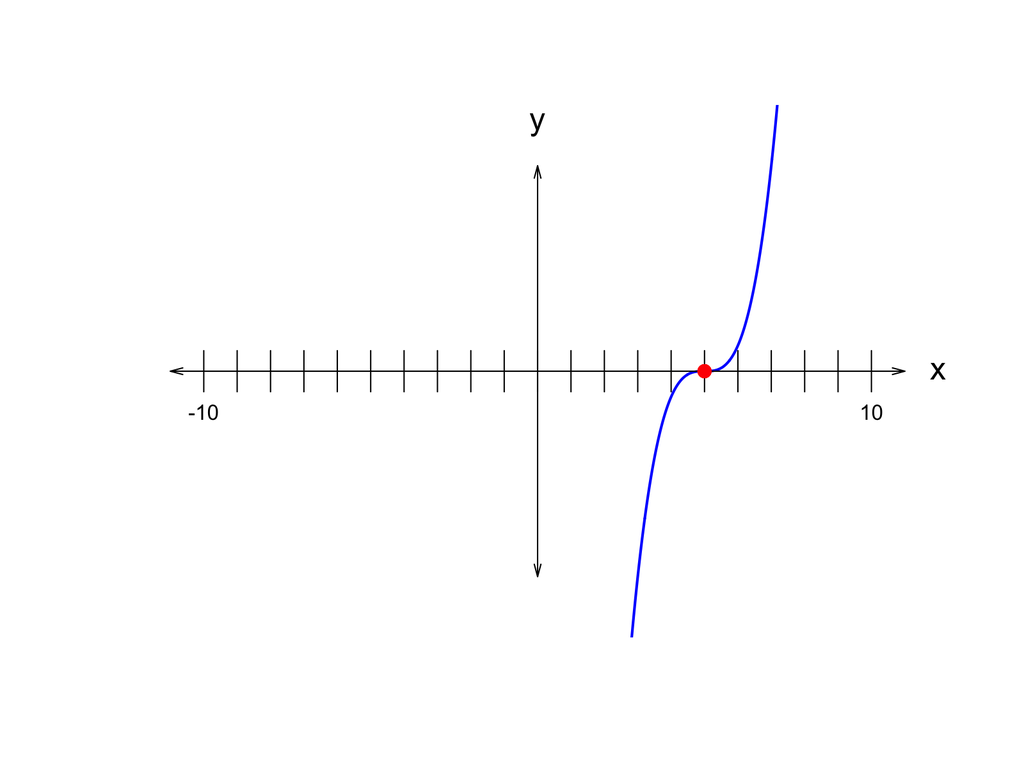

Find $B$, $C$, and $D$.

- $B=$
- $C=$
- $D=$

First, write the cubic polynomial in factored form (based on the three roots).

$$f(x)~=~(x-{5})(x-{5})(x-{5})$$

Partially expand the expression by writing $(x-{5})(x-{5})$ in standard form. To do this, we can use the FOIL method or a box.

| * | $x$ | $-5$ |
| --- | --- | --- |
| $x$ | $x^2$ | $-5x$ |
| $-5$ | $-5x$ | $25$ |

$$f(x)~=~
\left(x^{2}-{5}x-{5}x+{25}\right)(x-{5})$$

Combine like terms.

$$f(x)~=~
\left(x^{2}-{10}x+{25}\right)(x-{5})$$

Now, multiply the quadratic by the linear.

| * | $x^2$ | $-10x$ | $25$ |
| --- | --- | --- | --- |
| $x$ | $x^3$ | $-10x^2$ | $25x$ |
| $-5$ | $-5x^2$ | $50x$ | $-125$ |

$$f(x)~=~x^{3}-{5}x^{2}-{10}x^{2}+{50}x+{25}x-{125}$$

Combine like terms.

$$f(x)~=~x^{3}-{15}x^{2}+{75}x-{125}$$

Thus,

- $B=-15$
- $C=75$
- $D=-125$

A cubic polynomial, $f(x)$, is generated by randomly selecting the three parameters, $B$, $C$, and $D$, in the equation below.

$$f(x)~=~x^3+Bx^2+Cx+D$$

You know the graph $y=f(x)$ has one distinct real root at $x=4$. You could predict (due to the [inflection point](https://en.wikipedia.org/wiki/Inflection_point)), that the root at $x=4$ has multiplicity 3. Indeed, in this case, the multiplicity of the root is 3.

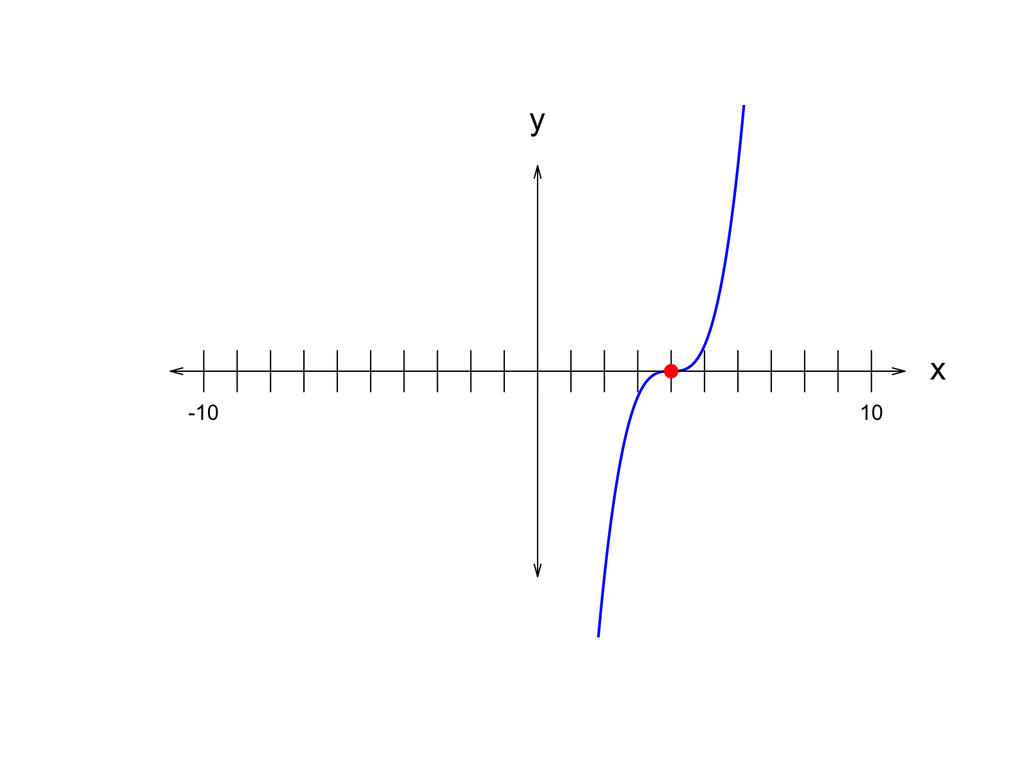

Find $B$, $C$, and $D$.

- $B=$
- $C=$
- $D=$

First, write the cubic polynomial in factored form (based on the three roots).

$$f(x)~=~(x-{4})(x-{4})(x-{4})$$

Partially expand the expression by writing $(x-{4})(x-{4})$ in standard form. To do this, we can use the FOIL method or a box.

| * | $x$ | $-4$ |
| --- | --- | --- |
| $x$ | $x^2$ | $-4x$ |
| $-4$ | $-4x$ | $16$ |

$$f(x)~=~
\left(x^{2}-{4}x-{4}x+{16}\right)(x-{4})$$

Combine like terms.

$$f(x)~=~
\left(x^{2}-{8}x+{16}\right)(x-{4})$$

Now, multiply the quadratic by the linear.

| * | $x^2$ | $-8x$ | $16$ |
| --- | --- | --- | --- |
| $x$ | $x^3$ | $-8x^2$ | $16x$ |
| $-4$ | $-4x^2$ | $32x$ | $-64$ |

$$f(x)~=~x^{3}-{4}x^{2}-{8}x^{2}+{32}x+{16}x-{64}$$

Combine like terms.

$$f(x)~=~x^{3}-{12}x^{2}+{48}x-{64}$$

Thus,

- $B=-12$
- $C=48$
- $D=-64$

A cubic polynomial, $f(x)$, is generated by randomly selecting the three parameters, $B$, $C$, and $D$, in the equation below.

$$f(x)~=~x^3+Bx^2+Cx+D$$

You know the graph $y=f(x)$ has one distinct real root at $x=3$. You could predict (due to the [inflection point](https://en.wikipedia.org/wiki/Inflection_point)), that the root at $x=3$ has multiplicity 3. Indeed, in this case, the multiplicity of the root is 3.

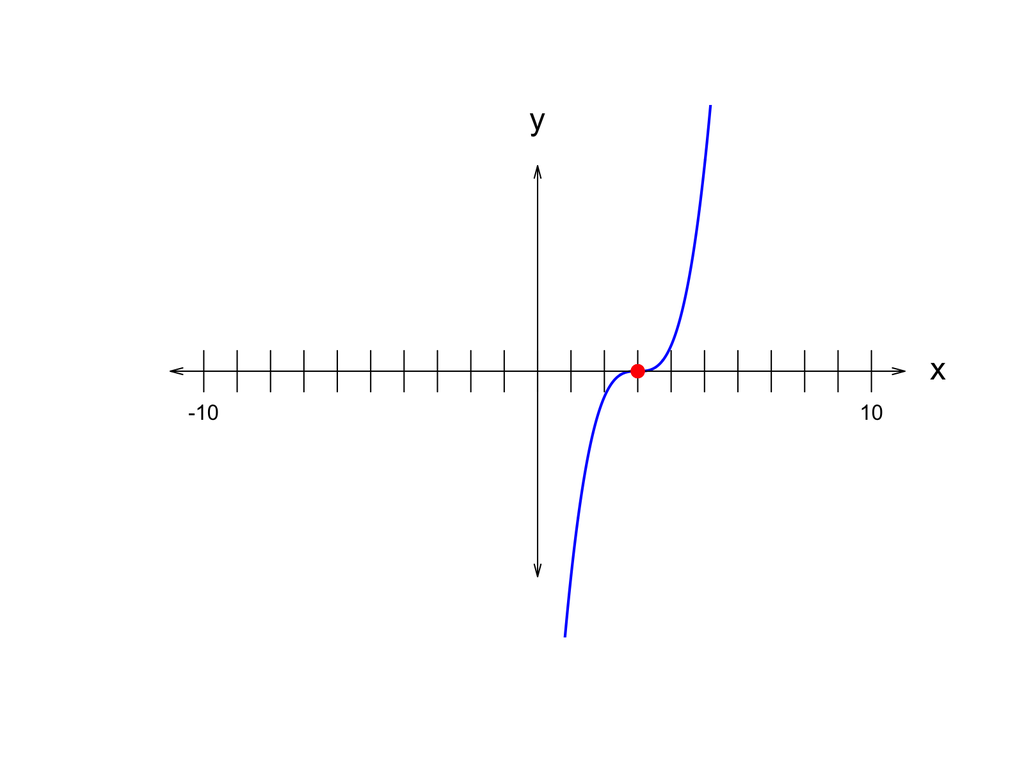

Find $B$, $C$, and $D$.

- $B=$
- $C=$
- $D=$

First, write the cubic polynomial in factored form (based on the three roots).

$$f(x)~=~(x-{3})(x-{3})(x-{3})$$

Partially expand the expression by writing $(x-{3})(x-{3})$ in standard form. To do this, we can use the FOIL method or a box.

| * | $x$ | $-3$ |
| --- | --- | --- |
| $x$ | $x^2$ | $-3x$ |
| $-3$ | $-3x$ | $9$ |

$$f(x)~=~
\left(x^{2}-{3}x-{3}x+{9}\right)(x-{3})$$

Combine like terms.

$$f(x)~=~
\left(x^{2}-{6}x+{9}\right)(x-{3})$$

Now, multiply the quadratic by the linear.

| * | $x^2$ | $-6x$ | $9$ |
| --- | --- | --- | --- |
| $x$ | $x^3$ | $-6x^2$ | $9x$ |
| $-3$ | $-3x^2$ | $18x$ | $-27$ |

$$f(x)~=~x^{3}-{3}x^{2}-{6}x^{2}+{18}x+{9}x-{27}$$

Combine like terms.

$$f(x)~=~x^{3}-{9}x^{2}+{27}x-{27}$$

Thus,

- $B=-9$
- $C=27$
- $D=-27$

A cubic polynomial, $f(x)$, is generated by randomly selecting the three parameters, $B$, $C$, and $D$, in the equation below.

$$f(x)~=~x^3+Bx^2+Cx+D$$

You know the graph $y=f(x)$ has one distinct real root at $x=2$. You could predict (due to the [inflection point](https://en.wikipedia.org/wiki/Inflection_point)), that the root at $x=2$ has multiplicity 3. Indeed, in this case, the multiplicity of the root is 3.

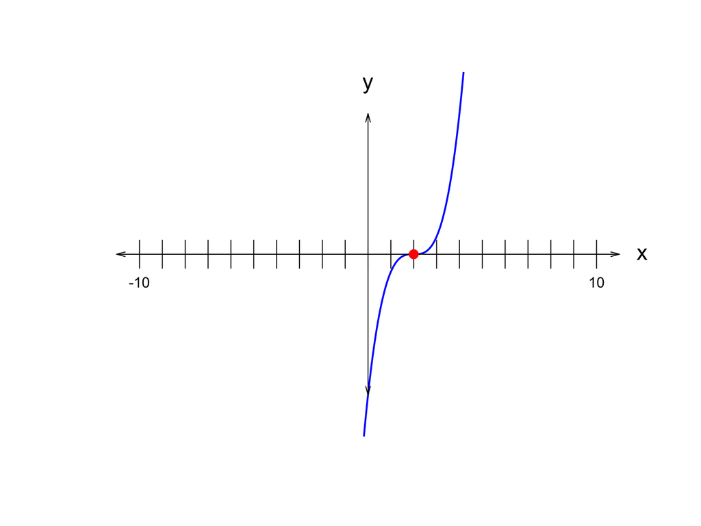

Find $B$, $C$, and $D$.

- $B=$
- $C=$
- $D=$

First, write the cubic polynomial in factored form (based on the three roots).

$$f(x)~=~(x-{2})(x-{2})(x-{2})$$

Partially expand the expression by writing $(x-{2})(x-{2})$ in standard form. To do this, we can use the FOIL method or a box.

| * | $x$ | $-2$ |
| --- | --- | --- |
| $x$ | $x^2$ | $-2x$ |
| $-2$ | $-2x$ | $4$ |

$$f(x)~=~
\left(x^{2}-{2}x-{2}x+{4}\right)(x-{2})$$

Combine like terms.

$$f(x)~=~
\left(x^{2}-{4}x+{4}\right)(x-{2})$$

Now, multiply the quadratic by the linear.

| * | $x^2$ | $-4x$ | $4$ |
| --- | --- | --- | --- |
| $x$ | $x^3$ | $-4x^2$ | $4x$ |
| $-2$ | $-2x^2$ | $8x$ | $-8$ |

$$f(x)~=~x^{3}-{2}x^{2}-{4}x^{2}+{8}x+{4}x-{8}$$

Combine like terms.

$$f(x)~=~x^{3}-{6}x^{2}+{12}x-{8}$$

Thus,

- $B=-6$
- $C=12$
- $D=-8$

A cubic polynomial, $f(x)$, is generated by randomly selecting the three parameters, $B$, $C$, and $D$, in the equation below.

$$f(x)~=~x^3+Bx^2+Cx+D$$

You know the graph $y=f(x)$ has one distinct real root at $x=-4$. You could predict (due to the [inflection point](https://en.wikipedia.org/wiki/Inflection_point)), that the root at $x=-4$ has multiplicity 3. Indeed, in this case, the multiplicity of the root is 3.

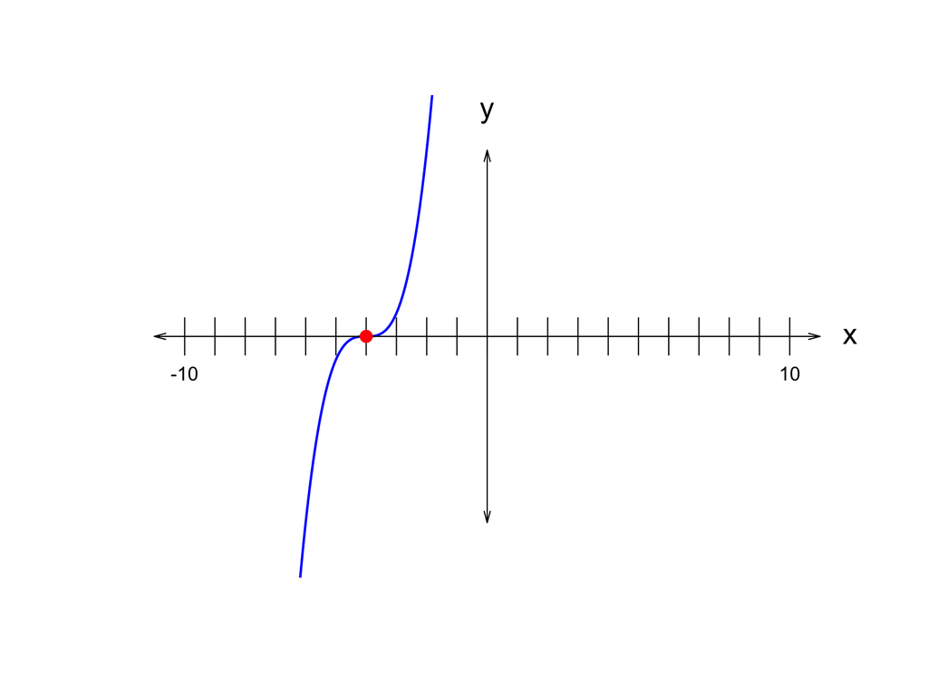

Find $B$, $C$, and $D$.

- $B=$
- $C=$
- $D=$

First, write the cubic polynomial in factored form (based on the three roots).

$$f(x)~=~(x+{4})(x+{4})(x+{4})$$

Partially expand the expression by writing $(x+{4})(x+{4})$ in standard form. To do this, we can use the FOIL method or a box.

| * | $x$ | $4$ |
| --- | --- | --- |
| $x$ | $x^2$ | $4x$ |
| $4$ | $4x$ | $16$ |

$$f(x)~=~
\left(x^{2}+{4}x+{4}x+{16}\right)(x+{4})$$

Combine like terms.

$$f(x)~=~
\left(x^{2}+{8}x+{16}\right)(x+{4})$$

Now, multiply the quadratic by the linear.

| * | $x^2$ | $8x$ | $16$ |
| --- | --- | --- | --- |
| $x$ | $x^3$ | $8x^2$ | $16x$ |
| $4$ | $4x^2$ | $32x$ | $64$ |

$$f(x)~=~x^{3}+{4}x^{2}+{8}x^{2}+{32}x+{16}x+{64}$$

Combine like terms.

$$f(x)~=~x^{3}+{12}x^{2}+{48}x+{64}$$

Thus,

- $B=12$
- $C=48$
- $D=64$

A cubic polynomial, $f(x)$, is generated by randomly selecting the three **real** parameters, $B$, $C$, and $D$, in the equation below.

$$f(x)~=~x^3+Bx^2+Cx+D$$

You know the graph $y=f(x)$ has one real root at $x=-4$. You are told that another (complex) root is $x=-6+{2}i$.

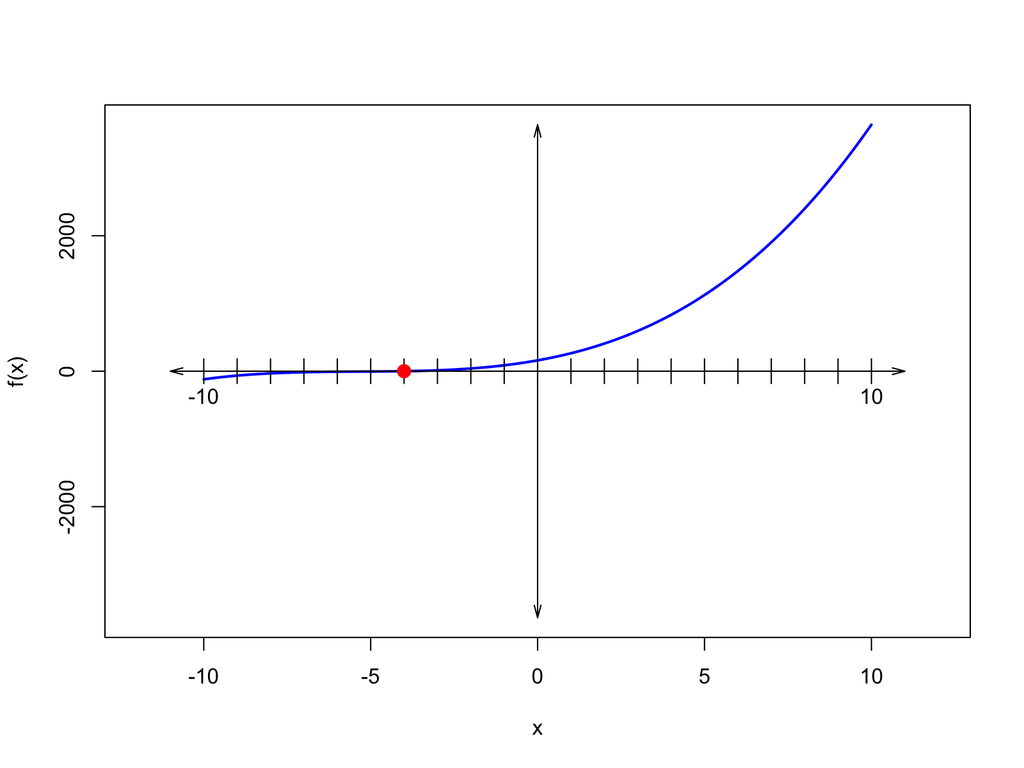

Find $B$, $C$, and $D$.

- $B=$
- $C=$
- $D=$

We know that complex roots come as pairs of complex conjugates. We are told $x=-6+{2}i$ is a root, so we also know $x=-6-{2}i$ is another root.

Write the cubic polynomial in factored form (based on the three roots).

$$f(x)~=~(x+{4})\cdot\left(x-(-6+{2}i)\right)\cdot\left(x-(-6-{2}i)\right)$$

I would expand $\left(x-(-6+{2}i)\right)\cdot\left(x-(-6-{2}i)\right)$ by first distributing across the internal parentheses to get $\left(x+6-{2}i\right)\cdot\left(x+6+{2}i\right)$ and then using the box method to multiply.

| * | $x$ | $6$ | $-2i$ |
| --- | --- | --- | --- |
| $x$ | $x^2$ | $6x$ | $-2ix$ |
| $6$ | $6x$ | $36$ | $-12i$ |
| $2i$ | $2ix$ | $12i$ | $4$ |

Combine like terms to get:

$$f(x)~=~(x+{4})\cdot\left(x^{2}+{12}x+{40}\right)$$

Now, we multiply again.

| * | $x^2$ | $12x$ | $40$ |
| --- | --- | --- | --- |
| $x$ | $x^3$ | $12x^2$ | $40x$ |
| $4$ | $4x^2$ | $48x$ | $160$ |

Combine like terms to get:
$$f(x)~~=~~
x^{3}+{16}x^{2}+{88}x+{160}$$

Thus,

- $B=16$
- $C=88$
- $D=160$

A cubic polynomial, $f(x)$, is generated by randomly selecting the three **real** parameters, $B$, $C$, and $D$, in the equation below.

$$f(x)~=~x^3+Bx^2+Cx+D$$